# SEI/CADE - 1164755 - Voto Ato de Concentração

**Ministério da Justiça e Segurança Pública - MJSP**

**Conselho Administrativo de Defesa Econômica - CADE**

SEPN 515, Conjunto D, Lote 4, Edifício Carlos Taurisano, - Bairro Asa Norte, Brasília/DF, CEP 70770-504  
Telefone: 61 3031-1283 - www.gov.br/cade

**Ato de Concentração nº 08700.004293/2022-32**

**Requerentes:** BASF SE, BMW Holding B.V., Henkel AG & Co. KGaA, Mercedes-Benz AG, Robert Bosch GmbH, SAP SE, Schaeffler Invest GmbH, Siemens Industry Software GmbH, T-Systems International GmbH, Volkswagen AG e ZF Friedrichshafen AG.

**Advogados:** Eduardo Caminati Anders, Marcio de Carvalho Silveira Bueno, André Santos Ferraz e Tatiane Kimie Matsumoto Siqui.

**Relator:** Conselheiro Gustavo Augusto.

**VOTO DO RELATOR – CONSELHEIRO GUSTAVO AUGUSTO**

**VERSÃO DE ACESSO PÚBLICO**

**Ementa**: ATO DE CONCENTRAÇÃO ORDINÁRIO. FORMAÇÃO DE *JOINT VENTURE*. CATENA-X. OPERAÇÃO GLOBAL. MERCADO DE FABRICAÇÃO DE AUTOMÓVEIS. MERCADO RELEVANTE DE ÂMBITO NACIONAL, dividido NOS segmentos DE Carros, veículos comerciais leves, ônibus e caminhões. EXISTÊNCIA DE SOBREPOSIÇÃO HORIZONTAL. PREOCUPAÇÃO concorrencial NOS SEGMENTOS DE ÔNIBUS E CAMINHÕES. SOBREPOSIÇÕES VERTICAIS E TRANSVERSAIS NO MERCADO DE PEÇAS AUTOMOTIVAS E NOS MERCADOS à MONTANTE.

1. Operação objeto de avocação por parte deste Tribunal, após aprovação inicial no âmbito da Superintendência-Geral, tendo sido convertida em Rito Ordinário.

2. Criação de joint-venture para a cooperação tecnológica, com ATUAÇÃO No mercado automobilístico. Acordo que prevê a cooperação entre montadoras de automóveis, empresas de TI e empresas fornecedoras de peças automotivas para o desenvolvimento de soluções digitais e para a troca de informações.

3. Preocupação concorrencial relativa à possibilidade de troca de informações concorrencialmente sensíveis entre empresas concorrentes.

4. APROVAÇÃO PARCIAL DO ATO DE CONCENTRAÇÃO, COM RESTRIÇÕES. não homologação do acordo proposto. DESIGNAÇÃO unilateral de remédios complementares. Aprovação do Ato de Concentração condicionadA à assinatura de Termo de Adesão, com remédios comportamentais e restrições de caráter permanente.

**voto**

A íntegra do relatório foi disponibilizada previamente (“Relatório”) (SEI nº 1102591), no qual constam, em detalhes, o andamento processual e os atos instrutórios relativos a este processo. Destaco alguns pontos que considero relevantes para a discussão que ora se inicia.

O presente Ato de Concentração (“AC”) anteriormente havia sido aprovado em rito sumário, sem restrições, no âmbito da Superintendência-Geral do CADE (SG/CADE), por meio do Parecer nº 338/2022/CGAA5/SGA1/SG (SEI 1093864) e do Despacho SG 1046/2022 (SEI 1093878).

Naquele momento, entendi ser necessário aprofundar a análise do AC para se compreender quais seriam as garantias efetivas que seriam dadas ao CADE, ao *Bundeskartellamt* e às demais jurisdições antitruste de que a *joint-venture* não seria usada como uma ferramenta de implementação do exercício abusivo de posições dominantes ou de eventual fechamento de mercado. Ademais, também julguei pertinente que fosse efetuada uma análise mais detida da operação, no que diz respeito à troca de informações feitas no ecossistema. Destaquei ser necessário se verificar se tais trocas de dados e de informações efetivamente respeitariam os limites da legislação antitruste, notadamente a brasileira, a qual não parecia ter sido especificamente analisada na documentação apresentada pelos Requerentes.

Nesse sentido, em meu Despacho Decisório nº 11/2022 (SEI 1100816), manifestei-me pela avocação do Ato de Concentração, indicando no referido despacho os principais pontos de preocupação, com seus respectivos fundamentos. O despacho citado foi homologado por unanimidade por este Tribunal, na 201ª SOJ. Posteriormente, a relatoria do referido processo acabou sendo distribuída aos meus cuidados, por sorteio.

Ato seguinte, proferi o Despacho Decisório nº 15/2022 (SEI 1112919), convertendo o Ato de Concentração em procedimento Ordinário, nos termos da Resolução CADE nº 33, de 2022. Naquela ocasião, solicitei que as requerentes prestassem esclarecimentos complementares, bem como juntassem os documentos necessários à compreensão da questão.

As Requerentes, em resposta ao despacho supracitado, juntaram manifestação (SEI 1123545) com as devidas respostas aos questionamentos, bem como com novos documentos do projeto, os quais me pareceram terem esclarecido adequadamente às questões indagadas por este Tribunal.

No curso deste AC, também foram realizadas reuniões com a *Fiscalia Nacional Economica*, autoridade responsável pela análise da Operação no Chile, e com o *Bundeskartellamt*, autoridade antitruste alemã, para troca de informações e compreensão da abrangência das análises efetuadas naquelas jurisdições.

Feita essa delimitação, passo à análise de mérito da Operação.

DAS REQUERENTES

A operação proposta consiste na formação, por meio do “*Joint Venture Agreement*” (“JVA”), de uma *joint venture* de cooperação tecnológica com sede na Alemanha, a ser formada entre as seguintes empresas: BASF; BMW; Henkel; Mercedes-Benz; Bosch; SAP; Schaeffler; Siemens; T-Systems; Volkswagen; e ZF, doravante referidas como “Partes” ou “Requerentes” da operação.

O **Grupo Volkswagen AG** é um grupo alemão que engloba as montadoras Audi, Man, Scania, Jetta, JAC, Porsche, entre outras montadoras e marcas de automóveis, possuindo uma divisão de veículos comerciais e uma divisão de caminhões e ônibus. Trata-se de um dos líderes mundiais na produção de veículos automotivos. O grupo possui mais de 100 unidades de produção em 83 países, valor de mercado de cerca de 111,8 bilhões de euros (mais de R$ 600 bilhões de reais) e faturamento global da ordem de 250 bilhões de euros, ou seja, superior a 1 trilhão de reais. No Brasil, o grupo possui 7 unidades industriais, sendo 5 sob a bandeira Volkswagen: 3 fábricas de automóveis, localizadas em Taubaté, SP; São Bernardo do Campo, SP; e São José dos Pinhais, PR; uma fábrica de motores, em São Carlos, SP; e uma fábrica de caminhões e ônibus, em Resende, RJ. Sob a bandeira Scania, o grupo possui uma unidade de fabricação de caminhões e motores, localizada em São Bernardo do Campo, SP. E sob a bandeira Audi, possui uma fábrica de automóveis em São José dos Pinhais, PR. As referidas unidades produzem veículos de todos os segmentos automotores (carros, veículos comerciais leves, ônibus e caminhões), além de produção de peças automobilísticas e motores.

A **Mercedes-Benz** faz parte do grupo alemão Mercedes-Benz Group AG, também com sede na Alemanha, com operações tanto no setor de automóveis como de ônibus e caminhões, além da fabricação de motores. A empresa possui mais de 300.000 empregados e faturamento global da ordem de 130 bilhões de euros, ou seja, superior a R$ 700 bilhões. A empresa também fabrica eixos, transmissões e outros componentes automotivos. No Brasil, a empresa possui três unidades industriais: duas plantas voltadas para caminhões, ônibus e peças automotivas, localizadas em Juiz de Fora, MG; e São Bernardo do Campo, SP; e uma unidade de peças automotivas, localizada em Campinas, SP.

A Bayerische Motoren Werke AG, **BMW AG,** é um grupo alemão que fabrica os veículos das marcas BMW, Rolls-Royce e Mini, atuando na produção de automóveis e de motocicletas. O grupo possui ativos de valor superior a 200 bilhões de euros (ou mais do que 1 trilhão de reais) e possui um faturamento anual, global, superior a 110 bilhões de euros (ou seja, superior a 500 bilhões de reais). O grupo possui mais de 100.000 empregados no mundo inteiro, com fábricas na China, EUA, México, Holanda, África do Sul, entre outras localidades. No Brasil, a BMW possui uma unidade industrial localizada em Araquari, SC, voltada à produção de automóveis.

A BASF SE, **Grupo** **BASF**, é uma empresa de capital aberto que atua nos setores químico e industrial e tem sede na cidade de Ludwigshafen am Rhein, na Alemanha. Na cadeia produtiva do setor automotivo, o Grupo BASF atua como fornecedor de catalisadores, fluídos automotivos, materiais para baterias, plásticos, revestimentos, entre outros insumos.

A Henkel AG & Co. KGaA, **Henkel**, é uma fabricante e fornecedora alemã de produtos de Lavanderia and Home Care, em particular de amaciantes e detergentes, bem como de produtos de limpeza doméstica. A Henkel também atua na produção de cosméticos e em tecnologias em adesivos. Na cadeia produtiva do setor automotivo, os produtos do Grupo Henkel incluem adesivos, revestimentos funcionais e selantes. Entre os produtos da empresa, destaco o Prepalene-X, produto aplicado na carroceria dos veículos para o preparo da superfície metálica para receber a pintura automotiva.

A Robert Bosch GmbH, **Bosch**, atua globalmente no fornecimento de produtos e serviços para os setores de soluções para mobilidade, tecnologia industrial, bens de consumo e energia e tecnologia predial. Na cadeia produtiva do setor automotivo, o Grupo Bosch oferta uma ampla gama de produtos e soluções, atuando praticamente em veículos de todas as montadoras e, também, no mercado de *aftermarket*. Além disso, em parceria com a Mercedes Benz, a empresa construiu um campo de provas para testes de veículos com um conjunto de pistas para desenvolvimento, testes e homologações de veículos leves e pesados<sup>[1]</sup> . No setor automotivo, a Bosch fornece peças como baterias, componentes elétricos, filtro de ar e de combustível, pastilhas de freio, alternadores, sensores, entre outras peças.

A SAP SE, **SAP**, atua no fornecimento de *enterprise application software* (“EAS”). Na cadeia produtiva do setor automotivo, a oferta de softwares pelo Grupo SAP inclui soluções para adoção e fabricação de veículos elétricos; soluções para “carros conectados” (*connected cars*); sistemas avançados de assistência ao motorista; soluções de mobilidade como serviço (“*mobility-as-a-service*” ou “MaaS”); e atuação no varejo digital automotivo. A empresa é diretamente ligada a várias empresas do ramo automotivo, incluindo a Mercedes, bem como atendendo a BMW e o Grupo VW.

A Schaeffler Invest GmbH, **Schaeffler,** atua globalmente nos setores automotivo e industrial. A Schaeffler atua no setor de chassis, motores e transmissão, além de soluções para rolamentos e mancais de deslizamento para um amplo número de aplicações industriais. Como fornecedora de peças da categoria alemã de corrida “DTM”, a empresa já participou da adoção de tecnologias inovadoras de condução nos carros de competição da Audi, BMW e Mercedes- AMG<sup>[2]</sup> . A empresa detém as marcas INA, FAG e LuK.

A Siemens Industry Software GmbH, **Siemens**, atua globalmente no setor de equipamentos de telecomunicação, material elétrico, energia, automação e digitalização de fabricação e processos industriais, soluções de mobilidade inteligente para transportes ferroviário e rodoviário, serviços digitais de saúde e em tecnologia médica. Na cadeia produtiva do setor automotivo, a linha de produtos da Siemens inclui soluções digitais para design de produtos, softwares para o setor automotivo, otimização e simulação de produção, design e automação de plantas, design integrado de chips, carregamento inteligente e produtos para avaliação e otimização em tempo real. Recentemente, a Siemens tornou-se a acionista majoritária da Electrify America, empresa subsidiária da VW que explora a recarga de veículos elétricos nos Estados Unidos e no Canadá<sup>[3]</sup> .

A T-Systems International GmbH, **T-Systems**, pertence ao Grupo Deutsche Telekom, que atua em tecnologia da informação e comunicação, ofertando rede fixa e de banda larga, comunicações móveis, internet, produtos IPTV e outros serviços e soluções de comunicação para consumidores e empresas. Na cadeia produtiva do setor automotivo, as atividades do grupo Deutsche Telekom incluem soluções para serviços digitais em veículos, atualizações *over-the-air* e o desenvolvimento e a operação de plataformas modulares e escaláveis – e.g., para condução autônoma. Recentemente, T-Systems e MAN Energy Solutions, **subsidiária da VW** que possui como produtos motores diesel, compressores e turbinas, firmaram contrato para transferência para *cloud* de toda a infraestrutura de TI da MAN<sup>[4]</sup> .

A ZF Friedrichshafen AG, **ZF**, atua globalmente no desenvolvimento, na fabricação e na distribuição de produtos e sistemas para veículos de passeio, veículos comerciais e tecnologia industrial. Na indústria automotiva, é um dos maiores produtores mundiais de peças automotivas, especialmente transmissões. Cito, por exemplo, a transmissão PDK produzida pela ZF e empregada em larga escala nos veículos da Porsche, sendo considerado uma das referências para transmissões de dupla embreagem, atualmente. Por meio da *ZF Lenksysteme*, em parceria com a Bosch, a empresa atua no setor de direção automotiva, incluindo produtos de direção EPS (Electric Power Steering).

Além das onze empresas fundadoras da joint-venture, a iniciativa Catena-X prevê a participação de membros associados. Atualmente, já são mais de 140 empresas associadas à iniciativa, destacando-se nomes como a montadora **Volvo** (por meio do Volvo Purchasing Group AB); a **Microsoft** (Microsoft Deutschland GmbH); a **Deutsche Telekom** AG; a **Accenture** (Accenture GmbH); a **IBM** (IBM Deutschland GmbH); a **Hewlett Packard** (Hewlett Packard GmbH); a **ThyssenKrupp** (ThyssenKrupp Materials Services GmbH); o grupo **Stellantis** (sucessor da Fiat-Chrysler e Citroen), o grupo **Ford**, entre tantas outras. Explico que o rol de empresas associadas à iniciativa é aberto, razão pela qual novas empresas poderão vir a participar do programa, ao longo da execução da presente operação. Além disso, o Catena-X se relaciona também com o projeto Gaia-X e com o IDSA (*International Data Spaces Association*), que inclui entre seus membros empresas como o **Google**, a **TIM**, o **Deutsche Bank**, entre outras.

O foco do Catena-X é o mercado automobilístico, congregando grandes montadoras de automóveis, fornecedores de peças automobilísticas e empresas de tecnologia. A iniciativa prevê uma maior integração tecnológica por meio de uma plataforma digital e de um ecossistema tecnológico, com o objetivo de possibilitar trocas de dados e de informações na cadeia produtiva do setor automotivo.

DO MERCADO RELEVANTE

A Joint-Venture em questão representará a união de vários competidores da indústria automobilística, notadamente das fabricantes Volkswagen, BMW, Mercedes-Benz, que usarão as plataformas do Catena-X para trocarem informações e melhor se integrarem com fornecedores de peças automobilísticas e com empresas de tecnologia. Por meio desta iniciativa, novos produtos tecnológicos poderão ser desenvolvidos para uso na indústria automobilística, tanto pelos consumidores finais como ao longo do processo de produção.

Sob a dimensão do produto, ao tratar da indústria automobilística, o CADE normalmente define o mercado relevante como sendo o de **fabricação e comercialização de veículos automotores**, o qual é divido em segmentos<sup>[5]</sup> . Adoto a segmentação do mercado de acordo com o critério da Anfavea, segmentando o mercado em: a) automóveis; b) veículos comerciais leves; c) caminhões; d) ônibus; e e) motos. Não me debruçarei de forma detalhada no segmento de motos, uma vez que a Operação trazida pelas Requerentes, em um primeiro momento, não traz maiores informações relativas ao mercado de duas rodas. Contudo, considerando a atuação da BMW e do Grupo VW (por meio da Ducati) na venda de motocicletas, entendo ser possível que a presente Operação também tenha influência nesse segmento.

Embora faça parte do mercado relevante, não trato, no caso em tela, da etapa de comercialização ou revenda de veículos, uma vez que a operação não parece ter relação com esse segmento da cadeia produtiva da indústria automobilística. Assim, entendo que a análise do presente caso deva se circunscrever à etapa de fabricação e às etapas da cadeia automobilística à montante.

Ainda sob a dimensão do produto, a jurisprudência deste Tribunal já subdividiu os segmentos acima de acordo com os tipos de veículo, para considerar a real substitutibilidade entre os bens, como devidamente discutido no Ato de Concentração nº 08012.010635/2009-34 (Volkswagen AG e Suzuki Motor). Sem pretender alterar a definição de mercado relevante constante nos referidos precedentes, entendo que, para o exame da presente *joint-venture*, o simples exame em segmentos mais amplos já se mostra adequado, notadamente diante do fato de não estarmos analisado uma operação de fusão clássica.

Sob a dimensão geográfica, o mercado relevante de fabricação de veículos vem sendo definido pelo CADE como sendo **nacional**<sup>[6]</sup> , embora, por vezes, avaliado sob a dimensão global<sup>[7]</sup> . No caso concreto, embora a operação como um todo tenha efeitos globais, efetuarei a sua análise à luz do **mercado nacional**, a qual já se mostra suficiente para a compreensão dos problemas concorrenciais em exame, no âmbito do presente voto.

Além do mercado relevante de fabricação dos veículos, explico que a *joint-venture* em tela poderá interferir em outros mercados relevantes relacionados à indústria automobilística, tais como: o mercado de autopeças; o mercado de soluções para a produção automatizada; o mercado de componentes de ferro fundido; o mercado de componentes de plástico; o mercado de sistemas de informação ao motorista; o mercado de sistemas de interiores; entre outros<sup>[8]</sup> . É certo que o real alcance da operação é de difícil antecipação, no presente momento, dado o caráter disruptivo da tecnologia em tela e da sua ampla gama de aplicações. Assim, entendo que pode ser difícil se definir, de forma precisa, todos os mercados relevantes que poderão vir a ser afetados pela operação em tela. Contudo, é bastante evidente que a *joint-venture* em questão tem o potencial de influenciar diversos mercados relevantes da cadeia automobilística, premissa essa que já se mostra suficiente para o presente exame.

Por metodologia, para melhor se evidenciar os problemas concorrenciais ora em apreço, passo a analisar a operação sob a ótica da **sobreposição horizontal** das principais montadoras envolvidas na operação: Volkswagen, BMW e Mercedes-Benz. Isso porque a tecnologia do Catena-X, produzida pela JV, poderá ser diretamente aplicada às suas respectivas linhas de produção, de forma uniforme, gerando efeitos horizontais no mercado.

Esclareço que efetuo a presente análise com base nos dados da Anfavea constantes do Anuário da Indústria Automobilística Brasileira 2022, dados esses que são de caráter público e de notório reconhecimento no mercado.

Passo, pois, à análise dos quatro segmentos do mercado relevante em exame: automóveis; veículos comerciais leves; ônibus; e caminhões.

Quanto ao **segmento de automóveis**, examinando-se os dados de veículos novos licenciados em 2021<sup>[9]</sup> , os números são o seguinte:

Audi<sup>[10]</sup> : 6.260

BMW: 15.948

Mercedes-Benz: 5.431

Volkswagen: 267.647  
Total: 295.286  
Total de automóveis licenciados no mercado nacional: 1.558.467  
Percentual: **18,9%**

Assim, tenho que, no segmento de automóveis, as empresas que compõe a JV não possuem poder de mercado significativo, com participação de mercado inferior a 20%, quando considerado o quantitativo total de automóveis novos licenciados no Brasil. A mesma conclusão pode ser obtida em relação ao segmento de veículos comerciais leves, no qual a participação de mercado é da ordem de 10%. Entendo, pois, que as preocupações neste segmento sejam menores, na ótica do mercado nacional, embora registre a possibilidade de outras montadoras de automóveis se associarem ao programa Catena-X, no futuro. Notadamente, aponto a possibilidade de integração da Ford e do grupo Stellantis (Fiat-Chrysler, Citroen e Peugeot) aos sistemas do Catena-X, o que ampliaria significativamente a margem de mercado referente ao segmento de automóveis, como examinarei a seguir.

De toda sorte, ao se considerar apenas as empresas componentes da JV, requerentes da presente operação, os segmentos que despertam maior preocupação concorrencial, sob a ótica horizontal, referem-se aos segmentos de **caminhões** e de **ônibus**. Isso porque os grupos em questão controlam os principais *players* do setor: Man (Volkswagen); Scania (Volkswagen); e Mercedes-Benz.

Confiram-se os números referentes ao licenciamento de **caminhões novos**<sup>[11]</sup> , em 2021, no mercado brasileiro:

Man: 37.462

Mercedes-Benz: 33.089

Mercedes-Benz Cars & Vans: 3.023

Scania: 15.611  
Total: 89.185  
Total de caminhões licenciados: 128.679,  
Percentual do mercado: **69,3% do mercado nacional**

Transcrevo, em seguida, os números referentes ao licenciamento de **ônibus novos**<sup>[12]</sup> , em 2021, no mercado brasileiro:

Man: 3.695

Mercedes-Benz: 5.832

Scania: 244  
Total: 9.771  
Total de ônibus licenciados: 14.062  
Percentual do mercado: **69,5% do mercado nacional**

Cumpre destacar que menciono os percentuais acima não como uma análise de concentração, eis que não estamos falando de uma operação de fusão clássica, razão pela qual se mostraria inadequada a aplicação dos critérios do "Guia H" do CADE. O que quero apontar é a **elevada probabilidade de uso de poder coordenado**, uma vez que há poucos fabricantes que atuam no mercado nacional nos segmentos de ônibus e caminhões, sendo certo que as empresas que integram a JV controlam parcela significativa dos referidos mercados.

Tenho, portanto, que as empresas requerentes **detêm elevado poder de mercado nos segmentos de ônibus e caminhões**, havendo uma maior facilidade para adoção de condutas colusivas e coordenadas. Registro, particularmente, que basicamente duas empresas, ambas integrantes da JV, dominam os referidos segmentos: o grupo Volkswagen, por meio da Man e da Scania; e o grupo Mercedes-Benz. Considero, também, que eventual troca de informações concorrenciais entre as duas empresas supracitadas pode vir a oferecer um risco significativo à competição, diante da sua inegável posição dominante.

Mais além, em que pese não figurarem como membros da JV ora analisada em tela, outras grandes montadoras também participarão da iniciativa do Catena-X, razão pela qual poderão ter acesso aos sistemas de TI da JV, inclusive com troca de dados, nos moldes propostos para a iniciativa. A título de exemplo, a Volvo, o Grupo Stellantis (união entre Fiat-Chrysler e Peugeot) e a Ford<sup>[13]</sup> também fazem parte da iniciativa do Catena-X<sup>[14]</sup> , embora não figurem como Requerentes da presente operação. Inclusive, ressalto que essa lista não é fechada, sendo possível que outras montadoras ingressem futuramente na associação, caso seja de seu interesse.

Considerando a possibilidade de atuação dessas empresas associadas, o poder de mercado no segmento de automóveis também se torna significativo. Somente a marca Fiat apresentou o número de 347.076 licenciamentos no ano de 2021<sup>[15]</sup> , sendo a líder no mercado brasileiro, com mais de 22,3% de *share*. A esse montante, também teríamos que somar as participações da Ford, da Peugeot e da Citroen, chegando-se a um share do mercado da ordem de **47%**. Ou seja, concorrentes que detém praticamente metade do segmento de automóveis estarão utilizando os sistemas de TI da JV, ora em exame.

Sob a ótica de caminhões e ônibus, a preocupação com o elevado poder de mercado é a mesma. Incluindo-se a Volvo na conta já indicada, encontraríamos níveis de poder de mercado ainda maiores nesses dois segmentos, sendo certo que os três grupos citados (Volkswagen, Mercedes e Volvo) detém a quase totalidade do mercado de caminhões e ônibus.

Estamos diante, pois, de uma integração envolvendo uma considerável parcela do mercado, a qual, se não analisada com o devido cuidado, poderá gerar significativos efeitos anticompetitivos no mercado automobilístico, de difícil reversão no futuro.

Cumpre apontar que os segmentos acima, analisados apenas sob a ótica da sobreposição horizontal, já demonstram o risco concorrencial da operação. Porém, **não afirmo com isso que o risco esteja restrito a esses segmentos, ou que seja restrito à sobreposição horizontal na produção de veículos**. Diante do caráter aberto do Catena-X, o qual permite o ingresso de novos atores, e considerando que a iniciativa congrega empresas importantes tanto do segmento de peças automotivas como de tecnologia da informação, é razoável se supor que o projeto **poderá gerar diversas sobreposições horizontais, verticais e transversais** ao longo da cadeia automotiva, cujo escopo é difícil de se antever, no atual estágio da operação.

O poder de mercado, no caso da operação em tela, deve ser avaliado sob a ótica de um **poder de mercado conglomerado**. Esse poder de mercado resulta da união de uma significativa quantidade de empresas dominantes em distintos segmentos da indústria automobilística e da indústria em geral. É razoável se supor que a cooperação entre as principais fabricantes de veículos com empresas dominantes em segmentos dos setores de peças automobilísticas, como a Bosch, Basf e a ZF Friedrichshafen, e com empresas dominantes em mercados de tecnologia, como a SAP, Siemens, Deutsche Telekom, Accenture, Microsoft, Siemens, IBM e Hewlett-Packard, poderá gerar sinergias significativas, capazes de impactar de forma expressiva toda a cadeia automotiva.

Essa grande sinergia de empresas dominantes, atuantes em distintos mercados relevantes, mas com atuações complementares entre si, pode gerar um significativo poder de mercado combinado, que não é nem horizontal, nem vertical, mas, sim, resultante de um **efeito conglomerado**. Nesse caso, uma das teorias do dano possível se dá pela possibilidade de uma “atuação transversal” e do exercício do poder de portfólio. *In verbis*:

A atuação transversal ocorre quando uma empresa emprega seu poder sobre um mercado específico para alavancar sua atuação em outros mercados, em especial quando se tratam de bens complementares ou relacionados. Tal teoria baseia-se no chamado poder de portfólio, ou seja, na possibilidade da adquirente (uma das requerentes) do ato de concentração induzir fornecedores ou clientes a contratarem a outra requerente nos mercados nos quais esta atua, não devido às características intrínsecas do produto e/ou serviço (e.g., preço, qualidade), mas devido ao conjunto de produtos e/ou serviços oferecido.

Segundo esta teoria, há condutas que podem ser incentivadas pela criação de conglomerados, em especial pelo aumento do poder de portfólio. As principais condutas são *tying* e *bundling*.<sup>[16]</sup>

Em casos de operações envolvendo a economia digital, como ocorre no caso dos autos, mostra-se cada vez mais pertinente efetuar análises do poder de mercado não com base apenas em sobreposições horizontais e verticais, mas considerando o poder de mercado do conglomerado como um todo. Ou seja, considerando o efeito conglomerado da operação e seus possíveis efeitos econômicos e competitivos, em uma análise mais ampla. Neste sentido:

Nesse contexto, não se pode descartar a possibilidade de que esses casos de condutas unilaterais na economia digital sejam um importante indicativo para questionamentos futuros quanto à eficácia de instrumentos de uma análise antitruste tradicional de atos de concentração que se baseia, preponderantemente, em sobreposições horizontais e integrações verticais.

Por consequência, análises de efeitos conglomerados tornam-se cada vez mais relevantes, não apenas devido ao ressurgimento de *players* gigantes, com potencial crescente poder de mercado e atuação transversal em vários setores da economia, como, também, devido a aquisições de empresas *mavericks*, por incumbentes, que comprometem, em determinados casos, a contestabilidade do mercado.<sup>[17]</sup>

Embora, no antitruste, costume-se analisar o poder de mercado com base em percentuais de participações de mercado, não podemos esquecer que esse método é uma simplificação, bastante útil, mas que serve apenas para se aferir quantitativamente uma noção econômica que é mais ampla: o **poder de mercado**.

O conceito de poder de mercado é, todavia, mais amplo do que simplesmente se apontar participações em volumes de faturamento ou em quantidade de produtos vendidos. De fato, a doutrina costuma definir o poder de mercado, do ponto de vista teórico, como a capacidade de uma empresa, ou um de grupo, de aumentar os preços acima dos níveis competitivos, por um período de tempo sustentável. Mas mesmo essa definição ainda é, de certa forma, restrita, pois o preço é apenas um dos fatores que podem ser influenciados por uma empresa dominante. Em uma visão mais abrangente, podemos definir poder de mercado como sendo a **capacidade de uma empresa de impor as suas escolhas sobre os competidores e consumidores**<sup>[18]</sup> .

No caso concreto, quando se considera que as diversas empresas dominantes em diversos segmentos do mercado automobilístico, ou de outros mercados a ele associados, decidem se juntar para estabelecer padrões e critérios de interoperabilidade, como ocorre no caso em tela, é inegável que essas escolhas poderão ser impostas aos consumidores e aos demais competidores. Essas escolhas poderão influenciar não só a forma de operação das linhas de montagem das fábricas, como poderão influenciar nos padrões de sistemas de informação ao motorista, nos sistemas interiores dos veículos, na indústria de autopeças, nos critérios de proteção ao meio-ambiente, nos padrões de segurança dos veículos a serem fabricados e mesmo na política de reciclagem de peças e de ELV (*end-of-life vehicles*). Voltarei ao tema do ELV, e da sua corrente preocupação concorrencial, em momento apropriado deste voto.

Operações conglomeradas, quando feitas no tipo de escala como a ora vislumbrada, também podem ampliar o poder político e econômico das empresas envolvidas, que são, assim, capazes de impor padrões transnacionais aos seus concorrentes. A imposição mandatória de padrões que beneficiam diretamente às empresas dominantes pode dar origem ao famoso efeito de *entrenchment*, efeito esse que pode inviabilizar a possibilidade de futura contestação do mercado, dando origem a novas e complexas barreiras de entrada. Sobre o tema, reproduzo as lições de William Kovacic e Ernest Gellhorn:

Conglomerate transactions take many forms ranging from short-term joint venture to complete mergers. […] A conglomerate merger also may convert a large firm into a dominant company with a decisive competitive advantage. A conglomerate merger may also reduce the number of smaller firms and increase the merged firm’s political power, thereby impairing the social and political goal of retaining independent decision making centers, guaranteeing small businesses opportunities, and preserving democratic processes.<sup>[19]</sup>

Deixo claro que a presente operação não é propriamente uma fusão de um grande conglomerado, eis que estamos diante de um contrato de *joint-venture*. Faço, assim, a presente reflexão não para discutir os níveis de concentração que serão obtidos pela operação, mas para explicar que a união de esforços de empresas do porte das que ora integram o Catena-X pode dar origem a um **significativo poder de mercado conglomerado**, o que justifica que os efeitos desta operação sejam analisados de maneira mais detida, sob a ótica concorrencial.

DA OPERAÇÃO NOTIFICADA

A operação proposta consiste na formação, por meio de um acordo, de uma *joint venture* de cooperação tecnológica, com sede na Alemanha e atuação global, formada entre as onze empresas requerentes, as quais englobam grandes fabricantes de automóveis, de autopeças e empresas de tecnologia. Além das onze empresas formadoras da *joint-venture*, a iniciativa Catena-X é aberta à entrada de outras empresas associadas, sendo certo que o projeto Catena-X já possui mais de uma centena de membros, além das Requerentes.

Conforme narram as próprias Requerentes (SEI 1080359), a partir da Operação, cada uma das Requerentes tornar-se-á acionista de uma empresa nova e independente, que é a joint venture - “JV”. Cada uma delas irá deter 9,1% do capital social da JV e os direitos de voto correspondentes. As Requerentes ressaltam em sua notificação que continuarão a atuar de forma autônoma e independente em seus respectivos mercados e segmentos.

A *joint venture* decorrente da Operação criará uma nova plataforma digital com o objetivo de possibilitar trocas de dados na cadeia produtiva do setor automotivo, a partir de padrões e critérios estabelecidos pelo Gaia-X e pelo Catena-X<sup>[20]</sup> .

A atuação da JV se dará dentro do escopo do Gaia-X e Catena-X, mas não se confunde com as respectivas associações. Há, pois, uma diferença entre a JV e a iniciativa Catena-X, sendo certo que a segunda é mais ampla do que a primeira. Como explicam as requerentes (SEI 1123545):

“No caso, a JV será a primeira empresa operacional constituída no contexto do Catena-X e terá o objetivo de operar uma plataforma para troca de dados baseada nos padrões Gaia-X e Catena-X.”

Por sua vez, a Associação Catena-X, intitulada Catena-X Automotive Network e.V., já se encontra em operação e não se confunde com a JV, ao menos em termos de personalidade jurídica. Contudo, há nítida sobreposição e atuação conjunta da JV com as iniciativas do Catena-X, Gaia-X e da IDSA (*International Data Spaces Association*).

Quanto à operacionalização de seu escopo de atuação, as Requerentes relatam que (SEI 1105289):

A plataforma da JV será operacionalizada como uma plataforma business-to-business (“B2B”), conectando players com atuação ao longo da cadeia produtiva do setor automotivo e implementando diversos “casos de uso” (“use cases”), **[ACESSO RESTRITO AO CADE E ÀS REQUERENTES]**, resultando em benefícios a todos os players com atuação na cadeia de suprimentos automotivos, aos consumidores finais e à sociedade como um todo.

Essa nova JV está diretamente associada à iniciativa do IDSA, porém com o olhar focado para a indústria automobilística. A iniciativa do *International Data Spaces* busca criar um padrão mundial de troca de dados entre diversos atores da indústria. Confira-se a explicação feita no próprio site da IDSA:

Nós reunimos inovadores globais para criar um futuro em que parceiros confiáveis, de todos os tamanhos e de todos os setores, **possam compartilhar dados com segurança**, mantendo a autodeterminação e o controle.

Direto para a economia digital!

A *International Data Spaces Association* (IDSA) é uma coligação de mais de 130 companhias que partilham uma visão de um mundo em que todas as empresas auto-determinam as regras de utilização e valorizam plenamente os seus dados em parcerias seguras, confiáveis e equitativas; e estamos tornando essa visão uma realidade.

**Nosso objetivo é nada menos do que um padrão global para espaços de dados internacionais** (IDS) e interfaces, bem como promover as tecnologias e modelos de negócios relacionados que impulsionarão a economia de dados do futuro em todos os setores. (Tradução nossa) <sup>[21]</sup>

Feito esse breve introito, passo a analisar a operação suscitada, bem como seus impactos concorrenciais.

Divido a minha análise em três partes distintas: primeiro, passo a delimitar o escopo da JV e sua relação com o Gaia-X e o Catena-X. Em um segundo momento, abordo como se dará a operacionalização da JV, baseado nas informações disponíveis até o momento. Por fim, antes de adentrar nos efeitos concretos da JV, analiso brevemente o mercado automotivo, destacando alguns pontos que reputo importantes para a formação do meu convencimento.

DA DELIMITAÇÃO DE ESCOPO DO GAIA-X, CATENA-X E DA *JOINT VENTURE*

Para o entendimento adequado da situação em tela, é necessário compreender o escopo que existirá por trás da atuação da JV, em especial seu aspecto regulatório.

A JV se insere no contexto do projeto Catena-X, que, por sua vez, se baseia nas premissas e pilares estabelecidos pela iniciativa conhecida como Gaia-X. Dessa forma, passo a caracterizar, de forma breve, em que medida o Gaia-X se interliga com o ecossistema Catena-X e, por fim, como essas iniciativas se relacionam com a atuação da JV em tela.

O Gaia-X pode ser assim definido (SEI 1080359):

O Gaia-X refere-se a um projeto que envolve mais de trezentas empresas, organizações acadêmicas e instituições políticas em todo o mundo. O Gaia-X não oferta diretamente infraestrutura, e tem o propósito de **estabelecer uma moldura (“framework”) para o gerenciamento de infraestruturas, dados ou serviços existentes**. A referida moldura pretende fomentar condições de igualdade sem implicar em “aprisionamento tecnológico” (“*vendor lock-in*”), de modo a ser constituída a partir dos princípios de acessibilidade irrestrita, comprovação de identidades, segurança e transparência. Operadores de infraestruturas, dados ou serviços poderão, dessa forma, adotar a moldura do Gaia-X e **implementar ecossistemas de dados** em conformidade com ela. A partir da adequação e implementação dos princípios do Gaia-X, objetiva-se garantir a confiança dos usuários em termos de controle, interoperabilidade e transparência dos ecossistemas, bem como a **interconectividade de dados e serviços**.

Pelo que pode ser percebido da análise da página inicial do seu site<sup>[22]</sup> , identifico que se trata de uma iniciativa para o desenvolvimento de um *framework* regulatório, ou autorregulatório, em matéria de transferência de dados para empresas. A iniciativa prevê uma série de princípios e padrões de conduta que reduziriam as assimetrias de informação, com o objetivo de gerar um aumento de eficiências nas trocas de dados, bem como uma melhor proteção de dados. Observo que o *framework* também tem como escopo mercados *B2B* (*business-to-business*).

A saber, a definição do escopa do Gaia-X que consta em sua página inicial é a seguinte:

Gaia-X é uma iniciativa que desenvolve uma estrutura de *software* de controle e governança e implementa um conjunto de políticas e regras que podem ser aplicadas a qualquer tecnologia de nuvem existente para obter **transparência, controle, portabilidade e interoperabilidade entre dados e serviços**. A moldura é planejada para ser implantada “por cima” de qualquer plataforma de nuvem existente que decida aderir ao padrão Gaia-X. (tradução nossa)<sup>[23]</sup>

Dessa forma, **a iniciativa Gaia-X não é propriamente um ator do mercado, nem opera os serviços exigidos para a aplicação do *framework* em tela**. Os serviços do Gaia-X serão criados, operados e adotados pelo mercado por meio da decisão dos diversos *players* e indústrias que decidirem adotar o padrão Gaia-X, em uma espécie de padrão de autorregulação.

Analisando seu código de conduta para *compliance* concorrencial, observo que o Gaia-X se trata, formalmente, de uma Associação sem fins lucrativos, com o objetivo de “promover e facilitar uma infraestrutura de dados federada e de software aberto (*open-source*) para fornecer e operar serviços de nuvem federados”.<sup>[24]</sup>

Mais além, a iniciativa Gaia-X ressalta, no mesmo documento, que tais *guidelines* são tão somente uma “visão geral” para a conduta de cada um de seus membros. Entre os princípios adotados para a manutenção de um ambiente concorrencialmente saudável, o Gaia-X prevê o **não** estabelecimento de (i) fixação de preços; (ii) divisão de mercado ou de consumidores; (iii) limites de produção; e (iv) **acordos ou troca de informações sensíveis**.

Embora a iniciativa Gaia-X não seja objeto da presente análise concorrencial, o Catena-X e o Gaia-X estão diretamente relacionados. Tal interconexão entre Gaia-X e Catena-X se revela, inclusive, na manifestação do tribunal concorrencial alemão, Bundeskartellamt (“BKT”) sobre o ecossistema, pano de fundo da operação ora em análise<sup>[25]</sup> . Em sua manifestação, o BKT ressalta que:

O Catena-X é um marco importante na iniciativa Gaia-X lançada pelo Ministério Federal de Assuntos Econômicos e Energia (agora Ministério Federal de Assuntos Econômicos e Proteção Climática) em 2019. O objetivo é criar uma infraestrutura de dados europeia, desenvolvendo interfaces e padrões para conectar diferentes serviços de nuvem entre indústrias. Isso visa reduzir a dependência de provedores de TI americanos e chineses. (tradução nossa)<sup>[26]</sup>

Cumpre explicar que o desenvolvimento do Gaia-X é apoiado financeiramente pelo próprio Ministério Alemão para Assuntos Econômicos e Proteção Climática, que disponibilizou um montante de, aproximadamente, cento em noventa milhões de euros para financiar projetos de diferentes setores econômicos baseados no Gaia-X<sup>[27]</sup> . Além disso, um representante do Ministério Alemão para Assuntos Econômicos e Proteção Climática faz parte do Conselho Consultivo da Associação Catena-X.

O Catena-X representa um dos primeiros ecossistemas em larga escala baseados nos princípios do Gaia-X e possui, como foco, a indústria automotiva. De acordo com as informações trazidas aos autos, percebo que o Catena-X pode ser segmentado em três elos distintos (SEI 1080360):

i. o cerne da iniciativa consiste em uma associação alemã sem fins lucrativos denominada “Catena-X Automotive Network e.V.”, da qual fazem parte mais de cem membros – incluindo as Requerentes – os quais compreendem empresas de tamanhos variados e institutos de pesquisa – trata-se de uma associação aberta à entrada de novos membros. A referida associação atua como uma instância de governança e padronização, desenvolvendo, promovendo e mantendo padrões e critérios a serem aplicados no ecossistema de dados. A associação coordena os trabalhos de desenvolvimento tanto quanto possível e procura implementar iniciativas relacionadas às suas atividades;

ii. as “coalizões de desenvolvimento” elaboram os trabalhos de desenvolvimento e funcionam como “grupos de trabalho” (“*workbench*”) do Catena-X. As referidas coalizões poderão ser formadas pelos membros da associação sem fins lucrativos ou por quaisquer terceiros – um dos princípios centrais da iniciativa (conforme detalhado abaixo) refere-se à sua ampla disponibilidade a terceiros para garantir a sua adoção na indústria automotiva e, potencialmente, em outras indústrias, bem como a permanente inovação. As soluções desenvolvidas em tais coalizões devem ser apresentadas à Catena-X Automotive Network e.V., que as avaliará de acordo com os princípios do Catena-X – e.g., acesso amplo e não-discriminatório, interoperabilidade, etc. – e as certificará como padrão;

iii. empresas operacionais constituídas no âmbito do ecossistema do Catena-X.

De maneira geral, então, percebemos que esses três elos compõe o ecossistema digital pertencente ao Catena-X. A operação notificada, como mais abaixo veremos, se insere no contexto de operacionalização do ecossistema. **E, para evitar eventual dúvida quanto ao verdadeiro objeto de minha análise, ressalto que a Associação Catena-X é independente da JV ora analisada.** Ressalto, ainda, que as Requerentes também fazem parte da Associação Catena-X, de forma independente. Em síntese, a *joint venture* se trata de um conjunto de empresas já pertencentes à Associação Catena-X, as quais, para operar em um elo específico de seu novo ecossistema digital, optaram por constituir uma nova entidade, em formato de JV.

Explico, por oportuno, que a operação em exame nestes autos não é a formação da Associação Catena-X, a qual, por sinal, já se encontra em operação. O que está sendo avaliado é a **formação de uma JV** entre as Requerentes, que irá, em síntese, desenvolver atividades de **cooperação para a inovação tecnológica, transferência de tecnologia e *know-how***, no âmbito do Catena-X. Note-se que nem todos as empresas associadas ao Catena-X integram a JV. O número de membros da associação é aberto e, hoje, já superior a uma centena de empresas. O número de empresas na JV, por outro lado, é limitado às onze Requerentes. Contudo, **todos os membros do Catena-X poderão vir a ser admitidos nos sistemas de TI da JV ora em exame**, na qualidade de **usuários**.

Para atuar na Associação Catena-X enquanto empresa operacional, a empresa precisa obter a “certificação Catena-X” junto à Associação Catena-X. De acordo com as Requerentes, isso garante o cumprimento dos padrões e princípios Catena-X, como, por exemplo, a interoperabilidade e segurança dos dados. (SEI 1123545)

**[ACESSO RESTRITO AO CADE A À REQUERENTES]**

**[ACESSO RESTRITO AO CADE A À REQUERENTES]**

Para ilustrar a diferença entre os três elos do ecossistema, destaco a própria apresentação do Catena-X, disponível em seu website oficial<sup>[28]</sup> :

[figure not shown]

No quadro vermelho, na imagem supra, indico o elo de atuação da JV analisada. Ou seja, as Requerentes atuarão no elo de operacionalização, elo esse que servirá à comercialização de soluções direcionadas à indústria automotiva como um todo. Isso é o que narraram as Requerentes, quando da notificação do AC (SEI 1080359):

A JV tem como objetivo a criação de uma **rede gerenciada em nuvem** (“*cloud*”) – com base nos princípios estabelecidos no âmbito do Gaia-X e do Catena-X – com **amplo acesso a todos os *players* do setor automotivo e seus respectivos parceiros** que desenvolvam atividades ao longo da cadeia produtiva do setor automotivo, possibilitando o **processamento de dados** e, assim, o aprimoramento de suas tomadas de decisão. Nesse sentido, a criação da referida rede permitirá, *inter alia*, a superação de desafios decorrentes da Indústria 4.0 ou de impactos da pandemia de Covid-19 na cadeia de suprimentos. Para tanto, a JV disponibilizará aos usuários de sua plataforma o acesso a seus serviços por meio de um único portal, o “Portal Catena-X”. Além disso, a plataforma será organizada por aplicativos de negócios (“*apps*”) relacionados a “casos de uso” (“*use cases*”) específicos – conforme detalhado a seguir – ou ainda de forma independente de tais aplicativos. Referidos aplicativos serão, primordialmente, desenvolvidos por terceiros – que poderão incluir as Requerentes – e a JV ofertará tais aplicativos a seus clientes por meio de um *marketplace* próprio (“*app store*”).

Isso posto, resta claro que a atuação das Requerentes se dará no elo de **operacionalização**. É importante compreender, portanto, quais serão suas atividades efetivas. Decerto, todavia, que há que se entender as incertezas naturais desta delimitação no atual estado do projeto, eis que se trata de um ecossistema ainda não plenamente estabelecido.

Nesse sentido, após o Despacho Decisório nº 15/2022 (SEI 1112919), em que solicitei maiores informações às Requerentes, questionei em que medida o projeto seria uma plataforma digital e, em que medida, tal operacionalização ocorreria. Após sua manifestação (SEI 1123545) as Partes indicaram o seguinte escopo de atuação:

No que se refere a *software*, **[ACESSO RESTRITO AO CADE E ÀS REQUERENTES].**

Do trecho acima, verifico que o modelo de negócios está fortemente baseado no desenvolvimento *softwares* e aplicativos voltados para a indústria automobilística*,* os quais serão comercializados diretamente, por meio de contratação específica para a sua elaboração, ou indiretamente, por meio do licenciamento desses aplicativos.

A esse argumento, adiciono o seguinte esclarecimento, constante na resposta à mesma questão (SEI 1123545):

Também é importante destacar que os aplicativos de negócios (“apps”) que poderão ser utilizados para trocas em “casos de uso” (“use cases”) específicos (e.g., **[ACESSO RESTRITO AO CADE E ÀS REQUERENTES]**) serão, essencialmente, desenvolvidos e ofertados por terceiros – que podem ser qualquer empresa interessada, incluindo os Acionistas. Em outras palavras, tais apps serão oferecidos aos usuários diretamente pelo provedor do app a partir do *marketplace* da JV (“*app store*”), integrado à plataforma. **A JV atuará essencialmente como intermediária entre os provedores de apps e os usuários da plataforma**. O fato de um *app* ofertado na plataforma ser obrigado a observar aos princípios do Catena-X – os quais são estabelecidos pela Associação Catena-X – e ser certificado adequadamente, não significa que o *app* tenha sido desenvolvido especificamente para a JV. Nesse contexto, vale notar que determinados *softwares* utilizados para a operacionalização da plataforma (e.g., **[ACESSO RESTRITO AO CADE E ÀS REQUERENTES]**) **poderão ser desenvolvidos pela JV**.

A atividade principal da JV, em resumo, refere-se à **operacionalização de uma plataforma de troca de dados para a indústria automotiva, baseada nos princípios do Gaia-X e do Catena-X.** Essa troca de dados se dará não só entre as Requerentes, mas entre todas as empresas cadastradas, o que poderá envolver múltiplos competidores e distintas etapas produtivas da cadeia automobilística. Esses dados e aplicativos, por sua vez, irão interagir com os *Data Spaces*, a cargo da IDSA (*International Data Spaces Association*). Os *Data Spaces* são, nesse caso, espaço de armazenamento de dados geridos por terceiros, utilizados para simplificar o gerenciamento de dados. No caso de projetos ligados ao Gaia-X, esses espaços são executados, principalmente, por meio da tecnologia de nuvem.

De forma sintética, a figura abaixo<sup>[29]</sup> ilustra as interações nos ecossistemas descritos:

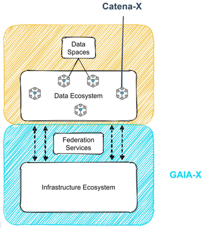

Feita a explicação das interações e diferenças entre Gaia-X, Catena-X e a JV, passo a uma breve análise de como se dará a atuação da JV, considerando os documentos juntados pelas Requerentes.

DA ANÁLISE DA ATUAÇÃO DA JV NO ECOSSISTEMA CATENA-X

O Catena-X oferecerá uma ampla variedade de produtos e serviços dentro de sua plataforma. São os chamados “casos de uso” (“*use cases*”), os quais permitirão a atuação das empresas participantes da JV em vários segmentos distintos do mercado automobilístico.

Até o momento, a Associação Catena-X assim afirma:

Desenvolvemos um total de 10 “*use cases*” iniciais, que cobrem uma ampla gama de tópicos. De tópicos como sustentabilidade à rastreabilidade, inúmeros problemas atuais na indústria automotiva são endereçados. O que todos os casos de uso têm em comum é **a abordagem de resolver os desafios não mais como uma empresa individual, mas com a ajuda de toda uma cadeia de valor**. Alguns casos de uso vão ainda mais longe e consideram não só a cadeia de valor, mas todo o ciclo de vida. (*Tradução livre. Grifei*)<sup>[30]</sup>

Resta claro, portanto, que **os participantes do Catena-X pretendem cooperar entre si para desenvolver produtos únicos para a indústria automobilística**. Contudo, essa cooperação pode ter efeitos negativos à competição, pois no lugar dos distintos competidores oferecerem produtos e soluções próprios, competindo entre si em termos de preço e qualidade, eles passarão a apresentar produtos e soluções tecnológicas únicas, que serão compartilhadas e utilizadas por distintos competidores. Por um lado, é possível que tal cooperação gere eficiências. Por outro lado, é igualmente possível que essa união de competidores diminua a competição e retire do consumidor final a possibilidade de escolher entre as diversas alternativas de produtos.

Destaco que essas são questões complexas, que envolvem o entendimento atual de toda uma cadeia de valor e, mais além, do desdobramento futuro dessa cadeia. Para tentar clarificar um pouco mais as questões ora postas, ilustro um dos contextos de atuação da JV a partir de informações existentes tanto nos autos quanto consultando a página oficial da iniciativa.

**[ACESSO RESTRITO AO CADE E ÀS REQUERENTES]**

**[ACESSO RESTRITO AO CADE E ÀS REQUERENTES]**

Da análise da imagem acima, percebo alguns pontos de destaque. Por exemplo, como já mencionado, as Requerentes do presente AC também fazem parte de outras iniciativas no mesmo ecossistema. A Volkswagen, por exemplo, além da participação na JV, também participa como Membro da Associação e integra a iniciativa de P&D, atuando em todos os elos do ecossistema Catena-X<sup>[31]</sup> . Mais além, da imagem se extrai que a atividade da Associação não se limita a uma única frente, mas sim busca englobar diferentes contextos do mercado automotivo em seus vários “*use cases*”, a serem implementados.

Há, por exemplo, a função de um “*Business Partner Data Management*”, ou BPDM, que nada mais é que um processo de gerenciamento de dados de parceiros de negócios, que permite a integração de empresas a partir de um único “registro” centralizado. Em outras palavras, o BPDM, no contexto do Catena-X, seria um dos “casos de uso” disponíveis no ecossistema, que permitiria a adoção de uma solução centralizada para reduzir o armazenamento de dados redundantes, diminuindo duplicidades e problemas de compartilhamento entre empresas pertencentes à Associação Catena-X, bem como reduzindo assimetrias de informação à medida que externalidades de rede comecem a se manifestar na plataforma.

Outro caso de uso a ser operacionalizada pela JV seria o da **“economia circular”**, aplicação essa que envolve a atividade de reciclagem de peças e de disposição de veículos que tenham ao final de sua vida útil, o chamado **ELV**.

<sup>[32]</sup> : **[ACESSO RESTRITO AO CADE E ÀS REQUERENTES]**

**[ACESSO RESTRITO AO CADE E ÀS REQUERENTES]**

Inúmeras outras funcionalidades são pensadas pela Associação. Da consulta ao seu site oficial<sup>[33]</sup> , pude extrair a seguinte imagem, que descreve os 10 “*casos de uso*” iniciais. Como pode ser observado, a iniciativa se propõe a ser muito mais do que uma integração vertical ou horizontal. Trata-se de um ecossistema que transversalmente aborda toda a cadeia de valor do mercado automotivo, desde a produção, passando por pesquisa e chegando à reciclagem e reinserção do insumo na cadeia produtiva:

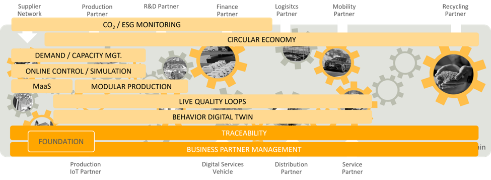

Claro que, em se tratando de uma Associação que busca prospectar novos membros, há que se analisar as imagens e alegações afirmadas com um viés de certo ceticismo pois, sem dúvida, há um elemento de convencimento publicitário existente em suas manifestações. Porém, acaso a iniciativa seja bem-sucedida, o seu potencial de impacto na indústria automobilística pode ser significativo e irreversível. **E a pretensão de atuação da referida iniciativa parece ser a mais ampla possível.**

Para além do simples *marketing*, observo que, em que pese o estágio inicial da JV e a ausência de subsídios fáticos das medidas a serem concretamente implementadas, seu *business plan* se propõe de maneira a, ao menos em um exame inicial, corroborar essas primeiras impressões.

Transcrevo, abaixo, a apresentação feita pela Volskwagen quanto ao Catena-X, que deixa clara **a pretensão de se gerar negócios e monetizar por meio da troca de dados**:

**[ACESSO RESTRITO AO CADE E ÀS REQUERENTES]**

O plano de negócios elaborado pela BMW, também Requerente, confirma a mesma estratégia, deixando claro que o produto a ser comercializado é o **dado**. De forma interessante, o fluxo de dado foi legendado como “Money Flow”, deixando claro que **dado e dinheiro convergem nesta operação**:

**[ACESSO RESTRITO AO CADE E ÀS REQUERENTES]**

O que verifico das apresentações acima é que o **racional econômico da operação estará exatamente na troca de dados**, que é a forma que as Requerentes parecem planejar produzir suas receitas.

Quando melhor se compreende o amplo escopo do programa, o nível de interação que será desenvolvido entre as empresas envolvidas, a pretensão de atuação de distintos competidores de uma forma conjunta e única e a criação de um ambiente especificamente criado para permitir a troca de dados entre empresas concorrentes, resta bastante evidente o potencial de a JV poder se transformar em um instrumento tecnológico para a adoção de condutas colusivas ou anticompetitivas.

Não quero dizer, com isso, que a iniciativa deva ser bloqueada, pois é inegável que a mesma poderá gerar eficiências, as quais poderão ser revertidas em favor do bem-estar do consumidor. Contudo, entendo que **devem as autoridades antitruste de todas as jurisdições estar vigilantes e atentas a esse tipo de iniciativa**, as quais devem ser acompanhadas de perto. Se, por um lado, a iniciativa pode gerar eficiências, por outro ela pode gerar efeitos negativos à concorrência, seja pela eliminação da competição, seja, no extremo, por viabilizar a formação de cartéis extremamente sofisticados, cuja operação será de difícil detecção por parte das autoridades de defesa da concorrência. Por tal motivo, **entendo que deva a operação em tela ser tratada com a adequada cautela e com um saudável grau de ceticismo**.

Feitas todas essas considerações, à luz dos documentos apresentados, sintetizo que a JV possui como objetivo principal o estabelecimento de uma **solução tecnológica digital** apta a (i) padronizar a troca de dados entre as empresas cadastradas; (ii) permitir a inclusão e cadastramento de novas empresas, que adotarão o ecossistema Catena-X em seus modelos de negócio; (iii) disponibilizar serviços de TI necessários para a troca de dados entre tais empresas; e (iv) monetizar esses serviços por meio do pagamento dessa troca de dados, bem como de taxas de transação, taxas de assinatura e taxas de registro. Esse ecossistema digital permitirá a cooperação entre as empresas participantes para o desenvolvimento de softwares, aplicativos e produtos digitais, os quais serão utilizados nas mais diversas etapas da cadeia automobilística, produtos esses que podem ser voltados tanto para o consumidor final como ser comercializados no modelo B2B (*business-to-business*).

Feitas essas considerações, passo a analisar algumas características do mercado automotivo que reputo serem importantes no contexto de análise da presente operação.

CONTEXTUALIZAÇÃO DA INDÚSTRIA AUTOMOTIVA

De maneira geral, o mercado automotivo de peças, de acordo com a jurisprudência do CADE, subdivide-se em um mercado primário, relacionado à veículos novos, e um mercado secundário, também chamado de *aftermarket,* destinado a peças de reposição. Em outras palavras, é a diferenciação entre *Original Equipment Manufacturer* (OEM) e o *Independent Aftermarket.*

Mais do que as marcantes diferenças de concorrência e de estrutura de oferta e de demanda, há uma miríade de *players* que orbitam a cadeia automotiva como um todo. Além das grandes montadoras de veículos, que são os principais atores desses mercados, a cadeia automobilística também engloba concessionárias de automóveis, oficinas mecânicas, revendedores de peças, vendedores de pneus e lubrificantes, prestadores de serviços financeiros, entre tantos outros.

À medida que o mercado automotivo se desenvolve tecnologicamente, novos serviços e empresas se agregam à supracitada cadeia produtiva. A título de exemplo, a inserção de tecnologias *wi-fi* nas centrais multimídia dos automóveis passou a demandar *know-how* na área de conexões e de redes, bem como uma maior integração com o setor de telecomunicações e informática.

Inovações tecnológicas desenvolvidas pelos fabricantes e montadoras tendem a afetar toda a cadeia produtiva. Por exemplo, a troca de veículos à combustão por veículos híbridos, ou totalmente elétricos, demandam toda uma nova cadeia de peças, que vão desde a parte elétrica de células de bateria até a parte computacional do automóvel.

Ademais, o mesmo veículo pode sofrer alterações em sua linha de produção pela alteração na disponibilidade de chips eletrônicos, polímeros plásticos, ligas metálicas, compostos químicos para a bateria, etc. Desde a pastilha de freio até o chicote de uma central eletrônica, temos ali diversas matérias primas, muitas vezes oriundas de diversas partes do globo, que geram efeitos em diversos outros mercados.

Nesse contexto, é natural que grandes conglomerados globais busquem se aproximar cada vez mais de uma padronização interna de seu portfólio, para superar esses problemas logísticos. Não à toa, o Grupo VW adotou a plataforma MQB para padronizar a produção de seus veículos, usando um mesmo padrão de plataforma a ser usado por veículos do tipo *Hatch,* passando pelos SUVs e até os Sedans. Igualmente, as marcas VW, Audi e Lamborghini compartilham certas peças OEM, embora se tratem de produtos voltados a públicos distintos de consumidores, referentes a veículos que não são substituíveis entre si. Sem sombra de dúvidas, a padronização reduz custos de produção, facilita economias de escala e reduz desperdícios, gerando benefícios tanto para os consumidores como para o próprio meio-ambiente.

Porém, cada fabricante é diferente entre si, exigindo peças e cadeias próprias para atender aos seus veículos. Isso pode gerar uma profusão de peças e empresas para lidar com as especificidades de cada marca.

[...] inexiste substituibilidade entre um farol e um para-choque (peças diferentes) ou entre uma lanterna esquerda do Ford Focus e uma lanterna esquerda do Fiat Uno (mesma peça elaborada para automóveis de modelos distintos). Para o consumidor que precisa adquirir uma peça de reposição – em razão de uma colisão, por exemplo – só há uma única peça capaz de restituir ao automóvel sua aparência e funcionalidade originais.<sup>[34]</sup>

Mais além, alterações em larga escala na linha de produção não são instantâneas. Elas demandam tempo e uma projeção futura de investimentos. A título de exemplo, o mercado automotivo brasileiro, no início dos anos de 2010, projetou um aumento da capacidade instalada para produção de veículos. Essa projeção não se manifestou no médio prazo e ocasionou uma capacidade ociosa significativa, em especial nos últimos anos. No caso nacional, a indústria automobilística acabou gerando uma capacidade instalada de produção apta a produzir cerca de **4,5 milhões** de veículos ano. Porém, a produção anual, em 2021, foi de apenas **2,24 milhões de veículos**, demonstrando a existência de uma significativa capacidade ociosa, da ordem de 50%<sup>[35]</sup> .

Nesse contexto, tenho que se **permitir uma maior cooperação** entre os atores para se obter uma maior previsibilidade e padronização **pode reduzir significativamente os custos de transação e assimetrias de informação**, eliminando ineficiências, naturais dessa indústria.

Todo o exposto anteriormente se relaciona no presente caso no seguinte ponto: o mercado automotivo é um mercado dinâmico, sujeito a flutuações em oferta e demanda nos mais variados elos da cadeia de produção. Assim, **parece ser justificável** que se admita a implementação de novas formas de cooperação e de ferramentas tecnológicas que **permitam minimizar os riscos** inerentes a este mercado.

Por outro lado, **este Conselho não pode fechar os olhos para o fato de que certos mercados relevantes específicos na indústria automotiva já são conhecidos por casos de cartelização**. Cito, como exemplo, os inúmeros casos envolvendo o mercado de autopeças automotivas.

Casos recentes, como o caso da TRW Automotive, envolveram a fixação de preços e condições comerciais, divisão do mercado entre concorrentes, troca de informações comercial e concorrencialmente sensíveis, alinhamento para aumento de preços e combinação de percentuais e datas para reajustes. Condutas anticompetitivas e formação de cartéis foram vistas em mercados como de produção e comercialização de válvulas para motor; rolamentos automotivos; velas de ignição; revestimentos de embreagem; sistemas térmicos, que incluem radiadores, condensadores e sistemas de aquecimento, ventilação e ar condicionado; limpadores de para-brisas; dispositivos de segurança para automóveis, como cintos de segurança e airbags; iluminação automotiva; embreagens; e mesmo em volantes de direção. Isso para se ilustrar apenas alguns dos diversos e repetitivos casos de cartel que o CADE já investigou, nos últimos anos, em relação à indústria em exame<sup>[36]</sup> .

A formação desses cartéis automotivos não é uma exclusividade do mercado brasileiro. Na União Europeia, destaco, também, o famoso “cartel dos caminhões”<sup>[37]</sup> . Além da fixação de preços combinada entre as montadoras para revenda de caminhões, os envolvidos também coordenaram a fixação de preços para novas tecnologias. Em resposta às regras de emissão de CO2 cada vez mais restritas na UE, as empresas decidiram estabelecer, também, o melhor momento de se introduzir tecnologias “mais sustentáveis”, propositalmente adiando a entrada em operação de tecnologias que seriam mais benéficas ao meio-ambiente. Cumpre ressaltar que o referido cartel envolveu pelo menos duas empresas integrantes de um grupo requerente da presente JV, bem como de uma outra fabricante de caminhões, igualmente integrante da associação Catena-X.

Em nível global, registro também o famoso *dieselgate,* escândalo de adulteração do *software* do sistema de injeção eletrônica de seus veículos, causando uma diminuição temporária na emissão de gases poluentes durante os testes de emissão de poluentes. Por sinal, também esse caso envolve uma das montadoras que ora figura no rol de requerentes da presente JV.

Registro que o caso Dieselgate teve um nível de sofisticação assombroso, pois os veículos eram fabricados com um dispositivo eletrônico especialmente desenvolvido para detectar quando eles estavam passando por testes de emissões pelas autoridades. Ao perceber o teste, o dispositivo alterava o funcionamento do motor, diminuindo a quantidade de poluentes emitidos. Durante o uso comum, no entanto, esses carros liberavam poluentes no ar em quantidades proibidas pela legislação norte-americana.

Temos, também, as recentes investigações na Europa, iniciadas pela *Competition and Markets Authority* (“CMA”) em março desse ano, no Reino Unido<sup>[38]</sup> em conjunto com a Comissão Européia, para analisar acordos relativos à reciclagem de veículos antigos, em especial carros e furgões, conhecidos na indústria como “*end-of-life vehicles" (ELV),* ou veículos em fim de vida, em uma tradução literal<sup>[39]</sup><sup>[40]</sup> . O caso está relacionado à regulação existente no âmbito da UE determinando que as empresas gerenciem sua frota de veículos, obrigando que 85% do peso do veículo seja reciclado ou reutilizado<sup>[41]</sup> . As investigações existentes analisam, precisamente, a adoção de uma conduta colusiva entre as empresas, para fixar preços no descarte e reciclagem desses veículos. Essa conduta parece ter sido confirmada, inclusive, pela Porsche, empresa pertencente ao grupo de uma das Requerentes do presente AC.

Considerando todo esse contexto, **não me parece razoável ignorar o fato que o histórico da indústria da automobilística não é o melhor, no âmbito de condutas anticompetitivas e de formação de cartel**. Não me parece ser o caso de, em nome de uma maior eficiência, optar por se ignorar os evidentes riscos de um ecossistema especialmente direcionado para a troca de dados acabar por viabilizar a troca de informações sensíveis entre concorrentes, de uma forma não detectável pelas autoridades antitruste. Inclusive, diante da sofisticação de casos como o do *dieselgate*, não se pode sequer descartar o risco de *softwares* e aplicativos serem desenvolvidos especificamente para fugir da fiscalização e permitir que tal troca seja feita de forma dissimulada, fora do olhar das autoridades antitruste das distintas jurisdições. Por tal motivo, há que se ter um olhar vigilante quanto às características das soluções digitais ora em exame.

Um exemplo desse risco seria um sistema digital que **automaticamente apagasse as mensagens** trocadas após um curto período de tempo, como ocorre em algumas mensagens de WhatsApp. Nesse caso, ainda que a autoridade antitruste tenha poderes para exigir o acesso a tais mensagens, **elas simplesmente não estarão mais disponíveis**. E como o ecossistema investigado também pode ser o proprietário do respectivo serviço de nuvem, pode ser que todos os rastros digitais sejam integralmente apagados, inviabilizando quaisquer investigações.

Deixo claro que não quero dizer, com isso, que seja esse o plano da JV ou de seus participantes. Mas este Conselho não pode ser ingênuo a ponto de ignorar esses riscos. Há que se considerar que, em termos de investigações em ambientes digitais, a vantagem estará sempre com o investigado, não com os investigadores. As autoridades de defesa da competição decerto possuem recursos materiais e pessoais significativamente modestos, quando comparados com os recursos disponíveis às empresas ora envolvidas na presente operação. Falo isso não em nome especificamente do CADE, mas considerando a situação real de **qualquer autoridade antitruste de qualquer jurisdição do globo**. Nesse contexto, é inegável a dificuldade de se conduzir uma investigação em um ambiente digital que seja plenamente controlado pelo próprio investigado. Por tal razão, é imperativo que a criação desse tipo de sistema preveja salvaguardas adequadas, aptas a viabilizar a *accountability* e o processo investigatório.

Um ecossistema como o ora delineado, sem sombra de dúvidas, pode gerar eficiências. Mas elas devem ser sopesadas com os riscos de dano à competição. Por exemplo, um dos “*casos de uso*” previstos, referentes à economia circular, pode reduzir a necessidade de matérias primas, à medida que a reciclagem e o reaproveitamento se integram novamente na cadeia de produção, o que seria o seu efeito positivo. Porém, se para se efetuar a reciclagem ou reaproveitamento de peças usadas for necessário o compartilhamento dos custos de descarte e reciclagem de tais peças, tal iniciativa, em que pese seu elemento inovativo e sustentável, também poderia propiciar a troca de informações concorrencialmente sensíveis, que podem gerar efeitos negativos muito superiores aos ganhos previstos, como, por exemplo, facilitando a formação de um cartel de fixação de preços ou de divisão de mercado.

Em que pese a iniciativa em exame ser disruptiva e capaz de gerar eficiências, a meu ver, **faz-se necessário prever um conjunto de salvaguardas que permitam mitigar os riscos da operação** e se garantir que a operação não gerará danos significativos à competição, ou, ao menos, que **eventuais danos não sejam superiores aos benefícios esperados**.

CONSIDERAÇÕES QUANTO AO RISCO DE COMPARTILHAMENTO DE INFORMAÇÕES CONCORRENCIALMENTE SENSÍVEIS

Em meu despacho anterior (SEI 1100816), pontuei a necessidade de uma análise mais detida ao caso, em especial quanto à estrutura da JV e sua operacionalização no mercado automotivo. As Requerentes alegam, nesse sentido, que as medidas e garantias de governança apresentadas seriam suficientes para mitigar os riscos concorrenciais de coordenação e troca de informações sensíveis.

Todavia, destaco que a mera existência de checagens de *compliance* para ingresso na Associação, por exemplo, são insuficientes, pois nada garantiriam quanto ao efetivo comportamento das partes após o ingresso, no curso da operação. A mera possibilidade abstrata de repressão posterior, em sede de controle de condutas, também parece ser insuficiente para coibir tais riscos concorrenciais. Isso se dá tanto em razão da evidente dificuldade de detecção da conduta, já detidamente comentado, como do tempo naturalmente dispendido nesse tipo de investigação, sendo certo que a resposta investigativa pode não ser tempestiva e, portanto, capaz de evitar a ocorrência de danos à competição e de exclusão de concorrentes mais eficientes.

As Requerentes também apresentaram uma “*comfort letter*”, encaminhada pelo *Bundeskartellamt* às Requerentes quando da análise da operação, a qual supostamente afastaria eventuais preocupações concorrenciais. A simples leitura do documento demonstra que não se trata de uma decisão colegiada, profunda, que tenha efetivamente analisado a operação, mas em simples resposta protocolar em face de operação informada em termos abstratos. Ao contrário, o que se verifica é que o *Bundeskartellamt* se reservou a prerrogativa de examinar a operação *ex post*, após a JV já ter entrado em operação.

Como é sabido, a constituição de uma *joint venture* não é de notificação obrigatória em várias jurisdições antitruste ao redor do mundo, incluindo, aqui, a legislação alemã. Nesse sentido, o documento do *Bundeskartellamt* sinaliza apenas uma ausência inicial de preocupações por parte da referida autoridade, emitida de forma perfunctória, indicando que se trataria de caso a ser avaliado em momento futuro. Ou seja, a posição adotada pelo BKT, em nenhum momento, parece ser conclusiva. Muito pelo contrário, sua manifestação é cautelosa e cercada de ressalvas.

Prosseguindo-se no exame, vale ressaltar que a Operação já apresenta alguns protocolos antitruste para disciplinar sua atuação. A saber, as Requerentes informaram que o ecossistema como um todo já possui as seguintes salvaguardas:

**[ACESSO RESTRITO AO CADE E ÀS REQUERENTES]**

Contudo, verifico que a atuação das equipes de experts em legislação antitruste, como a Hogan Lovells, que elaborou o guia aplicável, **somente se dá de forma interna à JV**, sem abranger a atuação das demais requerentes e usuários do sistema. Como a comunicação será feita diretamente entre os usuários, no modelo *peer-to-peer*, sem que qualquer dado seja disponibilizado ou armazenado pela JV, entendo que esses *experts* não teriam capacidade de realmente avaliar que tipo de informação está sendo efetivamente trocada pelos requerentes. Por esse motivo, os compromissos de *compliance* à legislação antitruste devem ser tomados não só com a JV ora formada, de forma interna, mas **devem se estender às empresas que formam a JV, bem como às empresas que troquem informações por meio dos seus sistemas.**

Sem a previsão dessas salvaguardas adicionais, a princípio, a Operação poderia resultar em um expressivo aumento dos riscos concorrenciais relacionados tanto ao exercício de poder coordenado, quanto de compartilhamento de informações concorrencialmente sensíveis. Esses riscos são aplicáveis não só às trocas de dados feitas entre as onze Requerentes da presente operação, mas também entre as demais empresas pertencentes ao ecossistema.

Em atenção a essas preocupações, as Requerentes apresentaram esclarecimentos em resposta ao item nº XXIX do Despacho Decisório 15/2022 (SEI 1112919), destacando as salvaguardas para mitigar os riscos concorrenciais. Por meio de sua manifestação juntadas aos autos (SEI 1123545), as Requerentes esclareceram o seguinte:

A iniciativa, desde o início, havia sido orientada de perto pelos departamentos antitrustes internos das Requerentes, bem como por um time jurídico externo especializado em Direito Concorrencial (Hogan Lovells), com diretrizes antitrustes abrangentes acordadas para cada elemento constitutivo da iniciativa do Catena-X;

Os Acionistas da JV já haviam se comprometido, no âmbito do JVA, a implementar um programa de *compliance* concorrencial robusto, conforme estabelecido na Cláusula 15 da JVA (SEI 1129151); e

O escritório que assessora a JV (Hogan Lovells) já havia estabelecido “Diretrizes Antitruste” específicas para a JV no Anexo 15.3 do JVA (SEI 1129151). Tais diretrizes regulamentam o desenvolvimento e a gestão das atividades comerciais da JV e a conduta das Requerentes na qualidade de Acionistas.

Procurando afastar as preocupações concorrenciais, as Requerentes destacaram que o escritório Hogan Lovells já havia conduzido nova avaliação detalhada que conclui pela conformidade com os princípios concorrenciais. Aproveito para expor as conclusões trazidas pelas Requerentes, em sua íntegra:

<sup>[42]</sup>

**[ACESSO RESTRITO AO CADE E ÀS REQUERENTES]**

Verifico da avaliação acima que os riscos de troca de informações sensíveis foram efetivamente identificados no diagnóstico feito pelo Hogan Lovells. Todavia, não identifiquei remédios específicos que fossem capazes de efetivamente prevenir as possíveis violações às normas antitruste no âmbito das Compromissárias, uma vez que o conteúdo das mensagens trocadas pelos usuários não estará acessível à JV.

A simples existência de diretrizes rigorosas, mas desprovidas de sanções ou de ferramentas que viabilizem a sua efetiva implantação, são simples promessas, palavras ao vento, incapazes de prevenir condutas maliciosas pelos que estejam realmente dispostos a violar as normas antitruste. E, pelos exemplos já listados anteriormente, decerto não há uma falta de pessoas dispostas a assumir riscos e violar as normas antitruste em busca do lucro ou de vantagens competitivas.

Em que pesem as medidas privadas adotadas para *compliance* das empresas serem um dos argumentos das Requerentes para justificar a aprovação sem restrições no Brasil, não me parece que elas sejam, por si só, suficientes para afastar as preocupações concorrenciais ora levantadas, diante da escala da operação, dos riscos concorrenciais envolvidos e do histórico anticompetitivo de parte dos envolvidos na operação. Nesse caso, deve a autoridade antitruste estar atenta ao Princípio da Precaução, **devendo evitar riscos ao mercado que sejam excessivos, desproporcionais ou irrazoáveis, quando comparados com os benefícios antevistos**. Há que se considerar, em especial, o papel do mercado automobilístico nacional nas cadeias produtivas globais, sendo certo que o Brasil é um dos maiores produtores de veículos automotivos do mundo, e um dos maiores mercados consumidores<sup>[43]</sup> . Tenho que considerar, ainda, os possíveis efeitos que a operação poderá ter no mercado automobilístico nacional, notadamente nos segmentos de ônibus e caminhões, diante da ampla dominância das requerentes nesse setor.

Registro que a JV formada, enquanto parte da estrutura do Catena X, segue as diretrizes do Gaia-X. Essas mesmas diretrizes indicam, em seu código de conduta, a necessidade de adequação às legislações antitruste ao redor do mundo, bem como da prevalência dessas em caso de conflito com o código de conduta da Associação. Ou seja, as próprias diretivas do Gaia-X corroboram que se adotem salvaguardas adequadas a se prevenir condutas anticompetitivas, **à luz das diversas legislações nacionais de defesa da concorrência.**

Feitas essas considerações, ressalto que a teoria antitruste é clara ao indicar que **a troca de informações concorrencialmente sensíveis entre competidores pode gerar efeitos anticompetitivos**, notadamente por facilitar a adoção de condutas colusivas e o exercício de poder coordenado. Especialmente quando efetuada em mercados altamente concentrados:

A principal forma que a troca de informações pode prejudicar os consumidores consiste em facilitar a colusão. O aumento artificial da transparência pode permitir que as empresas se envolvam e mantenham um comportamento coordenado ao longo do tempo. No entanto, embora a principal preocupação seja a coordenação, existem outras teorias não coordenadas sobre danos.<sup>[44]</sup>

Na Europa, o precedente emblemático a respeito de troca de informações sensíveis foi firmado em 1992, pela Comissão Europeia, no caso *UK Agricultural Tractor Registration*. Naquela ocasião, a Comissão concluiu que uma troca detalhada de informações sensíveis em um mercado altamente concentrado e não submetido a pressões competitivas externas aumentaria a possibilidade de condutas colusivas no mercado<sup>[45]</sup>.

No precedente do caso *Wirtschaftsvereinigung Stahl,* a Comissão entendeu que a troca de informações sobre as participações de mercado permitiria identificar os competidores que tentassem aumentar a sua participação de mercado, viabilizando a adoção de medidas de retaliação e eliminando os incentivos para a competição efetiva<sup>[46]</sup>. Essa troca de informações seria capaz de eliminar a "competição oculta", o que é considerado pela Comissão Europeia como uma violação ao art. 81.

Relembro, também, que muito antes desses precedentes, em 1984, a autoridade antitruste norte-americana já havia enfrentado a questão no caso GM-Toyota. Naquele momento, a autoridade antitruste permitiu a criação de uma joint-venture de produção entre a GM e a Toyota, no norte da Califórnia, para a produção de Chevy Geo Prizm e Toyota Corolla. A *joint-venture* foi aprovada, mas com uma proibição expressa de troca de informação sensível que não fosse necessária para a operação da fábrica. Naquela ocasião, embora a joint-venture não tivesse qualquer previsão expressa de troca de dados entre os concorrentes, a jurisdição norte-americana impôs obrigações de manutenção de registros (“*record keeping*”) e de apresentação de relatórios das informações trocadas, e foi imposto um monitoramento próximo das operações realizadas pelas empresas<sup>[47]</sup>.

Também a Autorità Garante della Concorrenza e del Mercato (AGCM), autoridade antitruste italiana, investigou a prática de acesso a um banco de dados comum por empresas de seguro concorrentes. Nessa ocasião, a AGCM entendeu que a formação de um banco de dados comum seria uma conduta anticompetitiva, implicando em prática concertada para a troca horizontal de informação sensível entre as competidoras<sup>[48]</sup>.

Em março de 2011, o *Bundeskartellamt* impôs uma multa de 38 milhões de Euros à Kraft, à Unilever e à Dr. Oetker por terem adotado uma prática de informarem-se mutuamente, com regularidade, a respeito das várias fases de negociações realizadas entre as empresas dos seus grupos econômicos e entre estas e os principais revendedores ativos nos respetivos mercados, incluindo planos de aumentos futuros<sup>[49]</sup> . Para o *Bundeskartellamt*, apesar dessa troca de informações entre os competidores não ter configurado uma formação de cartel, por não ter havido a efetiva fixação de preços, a autoridade antitruste alemã entendeu que esse tipo de conduta restringiria a competição de forma considerável. Cito, sobre o tema, a declaração do Presidente do *Bundeskartellamt*, sr. Andreas Mundt:

Certos tipos de troca de informações entre concorrentes são ilegais para o direito da concorrência. A concorrência é prejudicada por tais práticas, mesmo que não sejam acordos clássicos sobre preços, áreas de fornecimento, clientes ou cotas<sup>[50]</sup>

Verifico, portanto, que a doutrina antitruste norte-americana e europeia costumam impor grandes restrições à troca de informações entre competidores, tratando do tema com a máxima seriedade e de uma forma cautelosa e severa.

A jurisprudência nacional também corrobora minhas preocupações no presente caso. O CADE, historicamente, vem requisitando a adoção de *firewalls, ring-fencing* e programas de *compliance* robustos, bem como a condução dos negócios por uma administração independente, como medidas para endereçar preocupações ligadas à troca de informações concorrencialmente sensíveis (SEI 0919115).

Tal entendimento constou, por exemplo, nos Atos de Concentração nº 08700.002327/2018-78 (Votorantim/Tigre/Gerdau); 08700.003252/2016-81 (Dia Brasil/International Retail & Trade Services), 08700.002792/2016-47 (Bradesco/BB/Santander/Caixa Econômica/Itaú), 08700.004934/2019-53 (ADM/Bunge/Cargill/COFCO), 08700.010055/2014-56 (Albermale/Israel Chemicals); 08700.009902/2014-30 (BB Elo/Cielo), 08700.005305/2014-36 (Bradesco/BB); 08700.006723/2015-21 (Record/SBT/RedeTV), 08700.004872/2013-94 (Objetiva/Arqueiro/Record) e 08700.008607/2014-66 (Novartis/GSK).

A OCDE também publicou um extenso trabalho a respeito de troca de informações concorrencialmente sensíveis. Segundo a OCDE, no caso de informações trocadas no âmbito de *joint-venture* e acordos de P&D ou de padronização, a avaliação deve ser feita de forma direta, considerando os efeitos dessas práticas no âmbito do respectivo acordo:

Geralmente, as troca de informações entre concorrentes podem enquadrar-se em três cenários distintos sob a ótica da legislação concorrencial: (i) como parte de um acordo mais amplo de fixação de preços ou de partilha de mercado, em que a troca de informações funciona como um elemento facilitador; (ii) no contexto de acordos de cooperação mais amplos, tais como a formação de *joint ventures*, padronização ou Pesquisa e Desenvolvimento (P&D); ou (iii) como uma prática autónoma, em que a troca de informações é a única cooperação entre concorrentes.

A análise da concorrência da troca de informações nos dois primeiros cenários é relativamente simples. As agências de concorrência avaliam os possíveis efeitos restritivos de tais práticas em um contexto mais amplo de cartéis ou de acordos ao qual as trocas são elementos acessórios<sup>[51]</sup>

O caso concreto se enquadra exatamente na segunda hipótese apresentada pela OCDE: uma *joint-venture* envolvendo a cooperação em pesquisa e desenvolvimento (P&D) e padronização de produtos e serviços.

Ocorre que, no caso da operação em exame, a amplitude do projeto impede saber quais informações serão efetivamente trocadas pelos concorrentes. A iniciativa Catena-X é tão abrangente e ambiciosa, e suas aplicações encontram-se em fase tão embrionária, que não é possível se estimar, *ex ante*, quais serão os efeitos concretos dessa troca de informações. Diante desse ambiente de incerteza, e não estando claro quais informações serão efetivamente trocadas, há que se impor medidas protetivas para se evitar danos ao mercado e aos consumidores, **em moldes similares ao adotado pela autoridade antitruste norte-americana no caso GM-Toyota**.

Também chamo a atenção que, na União Europeia, está em andamento um processo de consulta pública para revisão dos *Guidelines* de Acordos Horizontais do Art. 101. Esse guia pretende, dentre outros pontos, endereçar exceções em bloco ("block excemptions") para acordos entre concorrentes voltados a P&D. Além das condicionantes aos acordos de P&D, que também envolverão acordos de *pooling* de dados, como é o caso do Catena-X, o texto da comunicação que a União Europeia divulgou subjacente à consulta pública traz algumas observaçoes bastante pertinentes sobre a sensibilidade de acordos entre concorrentes relativos a trocas de informações concorrencialmente sensíveis.

Destaco,, notadamente, as considerações do item 6.2.4.4 do guia acima referido ("The measures put in place to limit and/or control how data is used"). Algumas das medidas indicadas pela Comissão Europeia para limitar essas trocas coincidem, ou se assemelham, às medidas discutidas mais adiante no presente voto, tais como o uso de "times limpos" (*clean teams*), uso de medidas técnicas para que os usuários não obtenham informações sensíveis de seus concorrentes e a previsão de supervisão por um terceiro independente. Transcrevo, abaixo, os trechos pertinentes:

*Undertakings can for instance use clean teams to receive and process information. **A clean team generally refers to a restricted group of individuals** from an undertaking that are not involved in the day-to-day commercial operations and are bound by strict confidentiality protocols with regard to the commercially sensitive information. A clean team can for instance be used in the implementation of another horizontal cooperation agreement to ensure that the information provided for the purposes of such cooperation is provided on a need-to-know basis and in an aggregated manner.*

**Participants to a data pool should in principle only have access to their own information, and the final, aggregated, information of other participants.** **Technical and practical measures** can ensure that a participant is unable to obtain commercially sensitive information from other participants. **The management of a data pool can for instance be given to an independent third party** that is subject to strict confidentiality rules as regards the information received from participants in the data pool. Those who manage a data pool should also ensure that only information is collected that is necessary for the implementation of the legitimate purpose of the data pool.

Considerando todo o exposto, entendo presente o risco de poder coordenado das Requerentes. Entendo, ainda, que a simples adequação abstrata às medidas de *compliance* concorrencial, bem como as salvaguardas contratuais existentes no contrato da *Joint Venture*, não seriam suficientes, por si só, para afastar os riscos competitivos em tela, em especial a troca de informações concorrencialmente sensíveis. Agrava essas preocupações o fato que o objetivo central da *joint-venture* parece ser, precisamente, a troca de informações entre competidores.

Por todos esses motivos, parece-me que a consumação da operação deva estar condicionada à adoção de remédios específicos, aptos a darem efetividade aos *guidelines* antitruste da própria JV (SEI 112915), bem como necessários a se mitigar os riscos de condutas anticompetitivas e garantir a viabilidade de futura investigação, acaso alguma conduta anticompetitiva venha a ser efetivamente praticada. Todavia, entendo necessário que os remédios em tela sejam proporcionais, sem se impor excessivo custo na operação e sem se inviabilizar os possíveis ganhos de eficiência da operação.

DO ACORDO E DOS REMÉDIOS A SEREM APLICADOS

No intuito de endereçar as preocupações que apontei nesta análise, bem como para preservar as condições de concorrência nos mercados afetados pela operação, foram firmadas negociações entre as Requerentes e o meu Gabinete, nos termos do artigo 9º, incisos V e X, artigo 10º, inciso VII, e artigo 13, inciso X, da Lei nº 12.529, de 30 de novembro de 2011 (“Lei nº 12.529/2011”), combinados com o artigo 121, inciso II, e 125 do Regimento Interno do Conselho Administrativo de Defesa Econômica (“CADE”), aprovado pela Resolução nº 22 de 19 de junho de 2019 (“RICADE”).

No curso dessas negociações, as Requerentes concordaram em adotar um conjunto de medidas de *compliance* que preenchesse os requisitos estabelecidos por este Gabinete e que pudesse mitigar os riscos concorrenciais da operação.

Como resultado, em 18.11.2022, as Requerentes apresentaram uma proposta de Acordo em Controle de Concentrações – ACC (SEI 1151121), consolidando os remédios indicados, que seriam adotados para manter a operação em regime de equilíbrio com a competição que o mercado requer.

Além das diretrizes antitruste constantes no contrato da *Joint Venture*, entendo que a adoção permanente de medidas práticas de *compliance* concorrencial, acompanhada de um período inicial de monitoramento por este Conselho, aumenta a probabilidade de que o remédio seja efetivo, de uma forma estrutural.

Nesse sentido, no curso das negociações, as Requerentes indicaram as seguintes medidas adicionais:

**[ACESSO RESTRITO AO CADE E ÀS REQUERENTES]**

Do exame do ACC proposto, observo que foram indicados deveres e obrigações de preservação das condições de concorrência nos mercados relevantes afetados pela operação, em consonância com os princípios gerais de defesa da concorrência contidos na Lei nº 12.529/11. Ademais, todas as medidas sugeridas pelas Requerentes são propostas para adoção global, não se limitando somente à jurisdição brasileira; e aplicação integral, aplicando-se a todos os *players,* independente do poder de mercado

Registro, ainda, que as Requerentes propõem a contratação de um *Trustee* de monitoramento, às suas expensas, cuja nomeação dependerá de aprovação do CADE.

Entre os remédios sugeridos pelas Requerentes, destaco os seguintes:

As Requerentes deverão **armazenar parâmetros e registros de troca de dados** entre todos os seus usuários, em escala global, por um prazo de **5 (cinco) anos**. Esse armazenamento será efetuado no âmbito de cada usuário do sistema e organizados por um software especificamente desenvolvido para este fim, o *Eclipse Data Space Connector* (“EDC”), operado pela JV.

Também será adotado um programa de monitoramento das mensagens trocadas, realizado em dois pilares distintos:

I. Externamente, por auditor independente (*trustee*), com relatórios anuais de auditoria e com informação ao CADE de eventuais violações antitruste que venham a ser identificadas; e

II. Internamente, com a nomeação de um *Chief Compliance Officer (“CCO”),* encarregado por assegurar as diretrizes e *guidelines* aplicáveis, bem como o estabelecimento de ferramenta e fluxo de processos que permita a denúncia anônima de infrações antitruste.

As Requerentes deverão, também, adotar um *software* de rastreamento (*screening*) para identificar a troca de dados e arquivos potencialmente anticompetitivos, com a realização de auditorias periódicas. Esse programa irá monitorar as mensagens trocadas e disparar alertas ao CCO e ao *Trustee*, no caso de as conversas conterem indícios de violação às normas antitruste.

No caso de denúncia ou suspeita de ocorrência de uma violação às normas antitruste envolvendo o uso dos Sistemas de TI da JV e os mercados brasileiros, as Compromissárias e a JV se comprometem a cooperar com investigações conduzidas pelo CADE. A JV e as Compromissárias também se comprometem a investigar internamente essas denúncias, com o auxílio de investigadores independentes e sob o acompanhamento do *Trustee*.

Também será adotado um programa específico de proteção aos *whistleblowers* (denunciantes), inclusive com proteção contra a despedida arbitrária e contra o assédio moral, de forma a ser dar maior proteção às denúncias internas.

O desenvolvimento das soluções de TI deverá adotar um modelo de “*compliance by design*”. Para tal fim, os Sistemas de TI da JV devem ser concebidos e desenhados de forma integrar o cumprimento da legislação de defesa da concorrência às tarefas e processos de troca de informações, preferencialmente de forma automatizada.

Também faz parte dos remédios propostos a adoção de um programa de treinamento dos colaboradores para o cumprimento das normas antitruste.

O ACC também possui uma lista detalhada de informações que podem ou que não podem ser compartilhadas entre os usuários dos sistemas de TI da JV, com a qual estou plenamente de acordo.

Explico que as Requerentes propõe que a operação seja acompanhada pelo CADE e por uma auditoria independente (*Trustee* de monitoramento) pelo prazo de 5 (cinco) anos, a contar da consumação. Após esse prazo, será suspenso o monitoramento pela auditoria independente, sendo certo que todos os demais remédios e restrições serão mantidos em caráter permanente, enquanto a JV estiver em operação. Após o encerramento do período de monitoramento, caberá à própria JV supervisionar e continuar a executar as salvaguardas implementadas, cabendo ao CADE atuar apenas no caso de prática de alguma infração à ordem econômica (controle *ex post*).

Infelizmente, a proposta apresentada pelas Requerentes deixou de apresentar pontos importantes para o *enforcement* da operação, deixando de observar parte das orientações feitas por este Gabinete, no curso das negociações.

Em síntese, os pontos que deixaram de ser acrescidos, e que seriam essenciais, são os seguintes:

Compromisso de as empresas enviarem ao CADE o **conteúdo das mensagens** suspeitas trocadas pelo sistema de TI da JV (cláusula 3.3.2 do anexo), quando for aberta uma investigação de uma violação antitruste relacionada ao objeto desta operação e houver um pedido formal pelo CADE.

Necessidade de o Trustee apresentar declaração de **ausência de conflito de interesses** e não ter tido qualquer contrato ou vínculo trabalhista com a Associação Catena-X ou com as requerentes (item 3.7.2.3 do anexo).

Obrigação de o **Trustee informar quanto à troca ilícita de mensagens**, de informar quanto às violações do acordo e representar ao CADE quando quanto à necessidade de abertura de inquérito administrativo, quando tiver ciência de provas de cometimento de infração à ordem econômica (item 3.7.6.1 do anexo).

Responsabilidade de as Requerentes de, no caso de infração ou violação cometida pela JV ou por seus respectivos colaboradores, **efetuar o pagamento da multa**, se a mesma não for paga pela JV no prazo previsto no acordo (item 4.4.3).

Possibilidade de as **informações** relativas ao comprovado **descumprimento do acordo** **poderem ser tornadas públicas** e serem compartilhadas com as autoridades antitruste das demais jurisdições (item 6.4).

Previsão de que a **entrada em operação dos Sistemas de TI** da JV, com a possibilidade de efetiva troca de dados entre as Compromissárias, somente estará autorizada **após as salvaguardas** previstas no item 3 do acordo estarem em funcionamento (item 7.3).

Embora os remédios apresentados pelas Requerentes sejam parcialmente adequados, constato que a ausência das medidas de *enforcement* acima indicadas poderia colocar em dúvida a efetividade do acordo. Por esse motivo, entendo que as presentes complementações são essenciais para a aprovação da operação em exame. Particularmente, tenho que a ausência de garantia de acesso ao CADE em relação ao conteúdo das mensagens trocadas, no caso de abertura de investigação, bem como a ausência de previsão de o Trustee informar ao CADE quanto à existência de violações, esvaziam completamente o objetivo do acordo.

Como prevê o art. 128 do Regimento do CADE, no julgamento do pedido de aprovação do ato de concentração econômica, o Tribunal poderá: não conhecê-lo, aprová-lo integralmente, rejeitá-lo ou aprová-lo parcialmente, caso em que determinará as restrições que deverão ser observadas como condição para a validade e eficácia do ato, nos termos do art. 61 da Lei nº 12.529, de 2011.

Essas restrições podem ser objeto de acordo com as partes ou, não se chegando a um consenso, podem ser unilateralmente designadas pelo CADE. Sobre o tema, reproduzo o Guia de Remédios do CADE:

Desta forma, se o AC não for aprovado integralmente, a imposição de remédios constitui condição necessária para sua aprovação. Todavia, na impossibilidade de aplicação de remédios para uma operação que gere potencialmente prejuízo à concorrência, segundo o art. 88 da Lei 12.529/2011, o ato de concentração deve ser reprovado pelo Tribunal Administrativo do Cade (“Tribunal”).

Esses remédios podem ser negociados com as Requerentes, por meio de Acordo em Controle de Concentrações (“ACC”), integrante das recomendações da Superintendência-Geral do Cade (“SG”), quando da impugnação, ou de decisões do Tribunal, seguindo a regulamentação ditada pelo Regimento Interno do Cade (“RICADE”), em seus arts. 161, 165 e 168.

**Os remédios também podem ser designados unilateralmente pelo Tribunal do Cade** ou fazer parte de Termos de Compromisso de Cessação (“TCC”) em casos de infrações à ordem econômica advindas de condutas, no contexto dos arts. 36 e 38 da Lei 12.529/2011. Por conveniência da exposição abaixo, o tratamento dos remédios será referido apenas a ACs, embora sua aplicação possa ser dada a casos de condutas.

Não me parece ser o caso de reprovação sumária da operação, eis que entendo ser possível a aplicação de remédios adequados. Contudo, como o acordo proposto pelas partes se mostrou insuficiente, entendo cabível que o Tribunal designe unilateralmente os remédios a serem adotados. Nesse caso, poderão as requerentes se comprometer a adotar os remédios ora designados, hipótese na qual a operação poderá ser consumada; ou rejeitar os referidos remédios, hipótese na qual a operação será reprovada.

Tudo isso considerado, parece-me ser o caso de não se homologar o acordo. Entendo, contudo, ser possível a designação unilateral dos remédios e das restrições aplicáveis, como constante do anexo deste voto. Explico que o remédio e as restrições ora designadas adotam exatamente as mesmas ferramentas e soluções já sugeridas pelas Requerentes. Contudo, acrescento a esse conjunto de remédios e salvaguardas as medidas de *enforcement* descritas no item 165, consideradas essenciais. As empresas que assinarem o Termo de Adesão anexo a este voto, e se comprometerem a efetivamente adotar, na totalidade, os remédios já explicados, poderão integrar a JV. As que se recusarem, deverão se retirar da JV antes da consumação da operação e não poderão figurar como usuárias dos sistemas de TI da JV. **Não havendo adesão ao remédio ora designado, constante do termo anexo deste voto, tenho ser o caso de reprovação da operação.**

Dispositivo

*Joint ventures* concebidas para permitir a cooperação entre concorrentes para o desenvolvimento de atividade de Pesquisa & Desenvolvimento, ou formadas para fins de compartilhamento de soluções tecnológicas, devem ser dotadas de medidas efetivas para evitar o compartilhamento de informações sensíveis entre os concorrentes, notadamente em mercados propensos a condutas colusivas, como ocorre no caso concreto.

Verifico que o fato de o contrato da JV não prever o acesso ao conteúdo das mensagens trocadas pelos diversos usuários demostra que a atuação da JV, na forma contratual, não se mostra capaz de afastar as preocupações concorrenciais ora referidas. Assim, entendo ser necessária a adoção de remédios adicionais para impedir a troca ilícita de informações concorrencialmente sensíveis entre os concorrentes.

As partes apresentaram uma proposta de ACC que possui remédios parcialmente adequados. Contudo, o instrumento apresentado não veio acompanhado das medidas mínimas necessárias para garantir o *enforcement* e a credibilidade do acordo, como explicado acima. Por tal motivo, deixo de homologar o acordo apresentado.

Diante da rejeição do acordo, mas não sendo o caso de reprovação sumária, **DECIDO PELA APROVAÇÃO PARCIAL DA OPERAÇÃO, COM RESTRIÇÕES**, na forma do inciso VI do §2º do art. 61 da Lei de Defesa da Concorrência. Condiciono a aprovação da operação à assinatura do Termo de Adesão constante do anexo do presente voto, o qual reflete as restrições que entende este Tribunal serem necessárias para mitigar os possíveis efeitos nocivos do ato de concentração em julgamento. O referido termo possui remédios comportamentais, a serem monitorados por cinco anos, e restrições que devem ser mantidas em caráter permanente, enquanto a joint-venture existir.

O instrumento constante do anexo deste voto deverá ser assinado pelas Requerentes no prazo de até **45 (quarenta e cinco) dias** corridos, a contar da data da publicação da ata de julgamento desta sessão, **sob pena de reprovação da operação**. No caso de uma ou mais partes deixarem de assinar o termo de adesão constante do anexo deste voto, a operação poderá prosseguir apenas com as demais partes signatárias. Nesse caso, as partes que deixarem de aderir aos remédios ora previstos estarão **impedidas de participar da JV ou de ter qualquer acesso aos sistemas de TI da JV**, sob pena de multa diária de **R$ 250.000,00** (duzentos e cinquenta mil reais). Eventual retorno dessas empresas à JV, no futuro, dependerá de apresentação de nova notificação a este Conselho.

No caso de empresas que: i) tenham faturamento acima de **R$ 75 milhões anuais**, no mercado brasileiro; ii) **não sejam requerentes da presente operação**; mas que iii) decidam usar os sistemas de TI da JV para a troca de dados ou informação, ainda que apenas como usuárias de tais sistemas; **será obrigatória a apresentação de nova notificação ao CADE**, a qual poderá ser apresentada de forma conjunta ou isolada. Nesse caso, as empresas notificantes poderão optar por assinar o Termo de Adesão constante do anexo deste voto, com as devidas adaptações, ou demonstrar a inaplicabilidade das preocupações concorrenciais em tela às suas empresas. Essa notificação deverá ser prévia ao acesso a qualquer sistema de TI da JV, sob pena de a empresa incorrer na penalidade constante do §3º do art. 88 da Lei de Defesa da Concorrência. **Será obrigação da JV informar e exigir a necessidade da prévia notificação ora determinada a qualquer empresa** que venha solicitar o cadastramento para uso aos seus sistemas de TI, sob pena de aplicação de multa diária de R$ 100.000,00 (cem mil reais) para a JV.

Eventualmente reprovada a presente operação, pela recusa dos Requerentes em aceitar os remédios estabelecidos no termo constante do anexo deste voto, ficam os Requerentes impedidos de consumar a operação e de operacionalizar qualquer iniciativa conjunta no âmbito do Catena-X que envolva troca de dados ou informações, entre os mesmos ou com terceiros, ao menos até que nova notificação seja apresentada a este Conselho, sob pena de se submeterem às penalidades previstas na Lei de Defesa da Concorrência.

Poderão os requerentes consumar a operação após a assinatura do instrumento do Termo de Adesão com os representantes do CADE. Caso a operação seja consumada antes da devida assinatura do Termo de Adesão pelas partes, estabeleço a aplicação de multa diária no valor de **R$ 250.000,00 (duzentos e cinquenta mil reais)** para cada empresa envolvida, e consequente reprovação da operação.

Os sistemas de TI da JV somente poderão ser operados por usuários externos após as salvaguardas constantes no item 3.2 do Termo de Adesão terem sido implementadas e ter havido a efetiva nomeação do *Trustee* de Monitoramento. O início de operação desses sistemas sem as devidas salvaguardas implicará na pena de multa de R$ 100.000,00 (cem mil reais) por dia, para a JV e para cada Compromissária envolvida, devendo o uso do sistema de TI ser imediatamente interrompido até a implementação das medidas referidas. A referida multa será duplicada após 30 (trinta) dias corridos de descumprimento.

Esclareço que essa determinação não impede, todavia, que esses sistemas já comecem a ser desenvolvidos em ambiente de testes tão logo a operação seja consumada, desde que o sistema seja operado em um ambiente controlado, sem possibilidade de efetiva troca de mensagens entre as empresas concorrentes e sem acesso a usuários externos.

Além das obrigações previstas no item 3.7.6 do Termo de Adesão, e como detalhado no plano de trabalho, o *Trustee* de Monitoramento deverá: a) colaborar plena e ativamente com o CADE no monitoramento de todos os remédios previstos no Termo de Adesão; b) apresentar relatório específico referente ao início da operação dos sistemas de TI da JV, avaliando se as salvaguardas adotadas por esses sistemas atendem às restrições ora designadas; c) efetuar relatórios específicos para o caso de sistemas novos que venham a ser lançados durante o período de monitoramento, podendo tais relatórios englobar mais de um sistema ou aplicativo, se os mesmos forem suficientemente semelhantes; d) prestar quaisquer informações e relatórios que forem solicitados pelo CADE, no prazo de 15 (quinze) dias corridos, se não for concedido prazo maior pela autoridade antitruste; e e) incluir no seu relatório anual a listagem de todas as empresas que tenham sido cadastradas nos sistemas de TI da JV, indicando quais já estão operando nos referidos sistemas e verificando se as mesmas efetuaram a prévia notificação ao CADE, quando aplicável. O não cumprimento dessas obrigações poderá implicar na determinação de substituição do *Trustee*, observando-se o procedimento previsto no Termo de Adesão.

Em caso de descumprimento do estabelecido no Termo de Adesão, determino a aplicação das multas e sanções previstas no referido instrumento.

No caso deste Conselho verificar, no futuro, que os sistemas de TI da JV não são tecnicamente capazes de efetivamente obedecer às salvaguardas ora determinadas, ou se os Requerentes ou a JV fornecerem ao CADE informações deliberadamente falsas ou enganosas, a presente aprovação poderá ser revista, na forma do art. 91 da Lei de Defesa da Concorrência.

Nas demais hipóteses de descumprimento dos termos desse voto, para as quais não tenham sido previstas multas ou penalidades específicas, fixo a multa em R$ 250.000,00 (duzentos e cinquenta mil reais) por dia, para cada infração.

É como voto.

____________________________

**GUSTAVO AUGUSTO FREITAS DE LIMA**

Conselheiro

[assinado eletronicamente]

Anexos: I – Termo de Adesão

[1] “ Novo campo de provas da Mercedes-Benz com a Bosch começa a operar em 2023 com estruturas inéditas” Disponível em: https://tinyurl.com/2muh9a6o Acesso em novembro de 2022.

[2] “Space Drive: Steer-by-wire revoluciona o DTM “ Disponível em: https://tinyurl.com/2nrl3zwq Acesso em novembro de 2022.

[3] “ Volkswagen and Siemens invest in Electrify America’s ambitious growth plans” Disponível em: https://tinyurl.com/2fasg6rg Acesso em novembro de 2022.

[4] “T-Systems brings MAN Energy Solutions into the cloud”. Disponível em: https://tinyurl.com/2hy9jega Acesso em novembro de 2022.

[5] Ato de Concentração nº 08012.004507/2010-95 (Renault S.A. e Daimler AG) e Ato de Concentração nº 08012.002022/2012-29 (General Motors Holdings LLC e Peugeot S.A.).

[6] Ato de Concentração nº 08012.010635/2009-34 (Volkswagen AG e Suzuki Motor Corporation); Ato de Concentração nº 08012.003774/2000-73 (Daimler Chrysler AG e Mitsubishi Motors Corporation).

[7] Ato de Concentração nº 08700.005611/2022-82 (Tupy S.A. e International Indústria Automotiva da América do Sul Ltda.)

[8] Esses mercados relevantes foram definidos no precedente Fiat Peugeot. Ato de Concentração nº 08700.002193/2020-18 (Fiat Chrysler Automobiles N.V. e Peugeot S.A)

[9] Fl. 104 do Anuário da Indústria Automobilística Brasileira – 2022 – Anfavea. Disponível em https://tinyurl.com/2fmy6gm4 Acesso em novembro de 2022.

[11] Fl. 104 do Anuário da Indústria Automobilística Brasileira – 2022 – Anfavea. Disponível em https://tinyurl.com/2fmy6gm4 Acesso em novembro de 2022.

[12] Fl. 104 do Anuário da Indústria Automobilística Brasileira – 2022 – Anfavea. Disponível em https://tinyurl.com/2fmy6gm4 Acesso em novembro de 2022.

[13] Em que pese o encerramento da produção nacional, a Ford ainda possui uma significativa parcela de veículos em rodagem no país, em diversos modelos, bem como ainda sendo licenciados em caráter mais residual. Isso significa que tanto no comércio de veículos quanto no mercado de autopeças a Ford ainda possui relativa relevância no mercado brasileiro e não deve ser desconsiderada da presente análise.

[14] As empresas citadas não são fundadoras da JV, mas são membros associados. Fonte: “Our current list of members” Disponível em https://tinyurl.com/2n238fu5 Acesso em novembro de 2022.

[15] Fl. 68 do Anuário da Indústria Automobilística Brasileira – 2022 – Anfavea. Disponível em https://tinyurl.com/2fmy6gm4 Acesso em novembro de 2022.

[16] ATTAYDE, Maria Cristina de Souza Leão. EFEITOS CONGLOMERADOS NA JURISPRUDÊNCIA DO CADE. RDC, Vol. 9, nº 2. Dezembro 2021, p. 167.

[17] ATTAYDE, Maria Cristina de Souza Leão. EFEITOS CONGLOMERADOS NA JURISPRUDÊNCIA DO CADE. RDC, Vol. 9, nº 2. Dezembro 2021, p. 182.

[18] Sobre o tema, ver: GELLHORN, Ernest; KOVACIC, William E. et. al. Antitrust Law and Economics. 5ª Ed., p. 112-113

[19] GELLHORN, Ernest; KOVACIC, William E. et. al. Antitrust Law and Economics. 5ª Ed., p. 414-415.

[20] No decorrer de meu voto irei contextualizar o que cada uma dessas inciativas representa.

[21] No original: “We bring global innovators together to create a future where trusted partners, of all sizes and from all industries, can securely share data while maintaining self-determination and control. Straight ahead to the digital economy! The International Data Spaces Association (IDSA) is a coalition of more than 130 member companies that share a vision of a world where all companies self-determine usage rules and realize the full value of their data in secure, trusted, equal partnerships; and we are making that vision a reality. Our goal is nothing less than a global standard for international data spaces (IDS) and interfaces, as well as fostering the related technologies and business models that will drive the data economy of the future across industries.” Fonte: “IDSA: Driving data freedom for the whole world”. Disponível em: https://tinyurl.com/2frb8ps4 Acesso em novembro de 2022.

[22] “What we are”. Disponível em: https://gaia-x.eu/ Acesso em novembro de 2022.

[23] No original: “Gaia-X is an initiative that develops a software framework of control and governance and implements a common set of policies and rules that can be applied to any existing cloud/ edge technology stack to obtain transparency, controllability, portability and interoperability across data and services. The framework is meant to be deployed on top of any existing cloud platform that decides to adhere to the Gaia-X standard.” Disponível em: https://gaia-x.eu/. Acesso em novembro de 2022.

[24] “CODE OF CONDUCT. COMPETITION LAW COMPLIANCE” Disponível em https://tinyurl.com/2z6scdre Acesso em novembro de 2022.

[25] “First component for Gaia-X: Bundeskartellamt gives green light for establishing data network for automotive industry (Catena-X)” Disponível em: https://tinyurl.com/2mj3rn5j. Acesso em novembro de 2022.

[26] No original: “Catena-X is an important milestone in the Gaia-X initiative launched by the Federal Ministry for Economic Affairs and Energy (now the Federal Ministry for Economic Affairs and Climate Action) in 2019. The aim is to create a European data infrastructure by developing interfaces and standards for connecting different cross-industry cloud services. This is intended to reduce dependence on American and Chinese IT providers.”

[27] GAIA-X Entering its Operational Phase: Almost €190 m in funding for GAIA-X flagship projects. Disponível em: https://tinyurl.com/2qlkq2cb. Acesso em novembro de 2022.

[28] Disponível em https://tinyurl.com/2qqbde6m. Acesso em novembro de 2022.

[29] Figura adaptada. Fonte: https://tinyurl.com/2hhtm8z7. Acesso em novembro de 2022.

[30] No original: “We have developed a total of 10 initial use cases that cover a wide range of topics. From topics such as sustainability to traceability, numerous current issues in the automotive industry are addressed. What all use cases have in common is the approach of solving the challenges no longer as an individual company, but with the help of the entire value chain. Some use cases even go one step further and consider the entire life cycle”. Disponível em: https://tinyurl.com/2qvy4k4w. Acesso em novembro de 2022

[31] Sem sombra de dúvida, a iniciativa Catena-X se insere em um contexto maior, de desenvolvimento do mercado europeu como um todo. Não se trata, somente, da adequação regulatória ao fim de motores a combustão, por exemplo. Se trata, ao meu ver, de uma iniciativa com vistas a preparar o mercado para as novas dinâmicas que a frota elétrica impõe bem como diminuir a dependência à agentes externos, garantindo autonomia a diversos segmentos da indústria. A título de exemplo, VW e Bosch, ambas Requerentes no presente AC, firmaram memorando para explorar soluções industriais para células de bateria, que atualmente é um mercado com forte presença chinesa, sul-coreana e japonesa: “VW & Bosch team up to industrialize battery cell production in Europe”; disponível em: https://tinyurl.com/2gu9o8yu. Acesso em novembro de 2022.

[32] Schedule to Annex 35.1_Translation_English (SEI 1129136)

[33] “Benefits | Catena X” Disponível em https://tinyurl.com/2qvy4k4w Acesso em novembro de 2022

[34] Voto do Conselheiro Paulo Burnier. Processo Administrativo n° 08012.002673/2007-51, julgado em 14 de março de 2018.

[35] Dados da Anfavea relativos a 2021, constantes no anuário de 2022.

[36] Entre 2014 e 2017, a Superintendência-Geral instaurou treze Processos Administrativos para investigar cartéis de diferentes peças automotivas. Entre eles estão os processos relacionados aos segmentos de velas de ignição (PA 08700.005789/2014-13); rolamentos antifricção (PA 08012.005324/2012-59); revestimentos de embreagem (PA 08700.010321/2012-89); sistemas térmicos – que incluem radiadores, condensadores e sistemas de aquecimento, ventilação e ar condicionado (PA 08700.010323/2012-78); limpadores de para-brisas (PA 08700.010320/2012-34); dispositivos de segurança para automóveis – como cintos de segurança, airbags e volantes de direção (PA 08700.004631/2015-15); amortecedores (PA 08700.004629/2015-38); substratos de cerâmica para automóveis (PA 08700.009167/2015-45); peças automotivas de reposição (PA 08700.006386/2016-53); sistemas de exaustão e seus componentes (PA 08700.001486/2017- 74) e módulos de airbag, cintos de segurança e volantes para automóveis (PA 08700.002938/2017-35), válvulas para motor, guias de válvulas e assentos de válvulas (PA 08700.002904/2017-41).

[37] AT.39824 Trucks Disponível em: https://tinyurl.com/2j38lqva. Acesso em novembro de 2022.

[38] “CMA launches investigation into recycling of cars and vans” https://tinyurl.com/2q2q6qvy Acesso em dezembro de 2022

[39] “BMW fined by UK watchdog over information request”. Disponível em: https://tinyurl.com/2dt85v7p Acesso em dezembro de 2022

[40] “UK regulator investigates recycling of cars and vans“ https://tinyurl.com/2m2wx6pv Acesso em dezembro de 2022

[41] “Mercedes-Benz blows whistle in EU car-recycling probe” https://tinyurl.com/2ooy5mcu Acesso em dezembro de 2022

[42] (SEI 1123349)

[43] Nesse sentido, destaco que, do ponto de vista das montadoras, a própria Volkswagen tem no Brasil uma operação estratégica. Brasil e México, são dois polos fabris centrais para a empresa, que traz uma capilaridade e inserção bem grandes para a montadora. Mercedes Benz e BMW, em que pese ofertarem veículos de segmentos que poderiam ser considerados “mais premiums” em virtude do valor de seus modelos de acesso comercializados no país, também possuem uma boa comercialização, especialmente considerando o aftermarket de veículos usados. Bosch, enquanto fornecedora, fornece peças para uma miríade de segmentos, tanto na construção de novos veículos quanto em peças de reposição de veículos usados. Mais além, recente centro de testes construído em parceria entre Mercedes e Bosch tem o potencial de ser referência no país e na América Latina.

[44] No original: “The main way in which information exchanges can harm consumers is by facilitating collusion. Artificially increased transparency can allow firms to engage in, and sustain coordinated behaviour over time. However, whilst the primary concern is coordination, there are other non-coordinated theories of harm”. Fonte: “Information Exchanges Between Competitors under Competition Law” Disponível em https://tinyurl.com/2hteaf8p pg. 28. Acesso em novembro de 2022.

[45] “Information Exchanges Between Competitors under Competition Law” Disponível em https://tinyurl.com/2hteaf8p pg. 37. Acesso em novembro de 2022.

[46] Comissão Europeia, Decisão de 26 Nov 1997, Case IV/36.069, Wirtschaftsvereinigung Stahl, §39. Disponível em: https://tinyurl.com/2gx77ojd Acesso em novembro de 2022.

[47] “Antitrust Issues Related to Benchmarking and Other Information Exchanges: Federal Trade Commission”, (p. 21-23). Disponível em: https://tinyurl.com/2jx868wd Acesso em novembro de 2022.

[48] Caso RAS-Generali/IAMA Consulting, Bollettino 40/2004.

[49] “Bundeskartellamt concludes proceedings against consumer goods manufacturers on account of illegal exchange of information and imposes multi-million fine on Nestlé” Disponível em: https://tinyurl.com/2gnmpr6v Acesso em novembro de 2022.

[50] No original: “Certain types of information exchange between competitors are illegal under competition law. Competition is impaired by such practices, even if they are not classical hardcore agreements about prices, supply areas, customers or quotas.” Fonte: “Bundeskartellamt fines three manufacturers of consumer goods” Disponível em https://tinyurl.com/2zux6nho Acesso em novembro de 2022.

[51] No original: “Generally, information exchanges among competitors may fall into three different scenarios under competition rules: (i) as a part of a wider price fixing or market sharing agreement whereby the exchange of information functions as a facilitating factor; (ii) in the context of broader efficiency enhancing cooperation agreements such as joint venture, standardization or R&D agreements; or (iii) as a stand-alone practice, whereby the exchange of information is the only cooperation among competitors. The competition assessment of information exchanges in the first two scenarios is relatively straightforward. Competition agencies assess the possible restrictive effects of such practices in the broader context of the cartel or the agreement to which they are ancillary”. Fonte: “Information Exchanges Between Competitors under Competition Law” Disponível em https://tinyurl.com/2hteaf8p pg. 9. Acesso em novembro de 2022.

|  | Documento assinado eletronicamente por **Gustavo Augusto Freitas de Lima**, **Conselheiro**, em 20/12/2022, às 12:29, conforme horário oficial de Brasília e Resolução Cade nº 11, de 02 de dezembro de … |
| --- | --- |

|  | A autenticidade deste documento pode ser conferida no site sei.cade.gov.br/autentica, informando o código verificador **1164755** e o código CRC **DC9CBEFE**. |
| --- | --- |

| **Referência:** Processo nº 08700.004293/2022-32 | SEI nº 1164755 |
| --- | --- |